# Final Project - Bitcoin Price Analysis and Forecasting

2024-12-30

# Contributors

**Group-5**

- Md Fahim Shahriar Chowdhury -**243000561**
- Subrata Das - **243000661**
- Mafia Rahman Tule - **243001461**
- Mohammad Helal Uddin-**243002461**
- Wasim Kabir - **243002561**

# 1. **Objective of the Project**

We have covered Regression & Time Series analysis in details. The main purpose of this project is to implement the acquired knowledge in real life situation.

In this project we are expected to perform Regression & Time Series analysis and forecasting techniques on Bitcoin historical price. The experience can be replicated to forecast Stock price & Currency price as well.

# 2. **DataSet**

You are given a dataset of Bitcoin (BTC) historical price against USD. This is a monthly average price dataset having prices from 01 January 2015 to 30 November 2023.

# 3. **Applied Models**

1. Linear regression model
2. Quadratic regression model
3. ARMIA model

# 4 **Task Performed**

# 4.1 **Loading the Dataset**

```r
# Loading the dataset into a dataframe named BitCoin
BitCoin <- read.csv("BTC-Monthly.csv")

#   Checking the data types of the features.
str(BitCoin)
```

```
## 'data.frame':    107 obs. of  2 variables:
##  $ Date : chr  "2015-01-01" "2015-02-01" "2015-03-01" "2015-04-01" ...
##  $ Close: num  217 254 244 236 230 ...
```

```r
#   Assigning appropriate data type to features.
# Converting Date column to Date type
BitCoin$Date <- as.Date(BitCoin$Date)

# Checking the structure of the data frame.
str(BitCoin)
```

```
## 'data.frame':    107 obs. of  2 variables:
##  $ Date : Date, format: "2015-01-01" "2015-02-01" ...
##  $ Close: num  217 254 244 236 230 ...
```

```r
#   Checking if there’s any missing value in each column
colSums(is.na(BitCoin))
```

```
##  Date Close
##     0     0
```

```r
# Get total number of missing values in the entire dataframe
cat("\nTotal missing values in the dataframe:", sum(is.na(BitCoin)))
```

```
##
## Total missing values in the dataframe: 0
```

# 4.2 **Descriptive Analytics**

## • Create a monthly boxplot of prices.

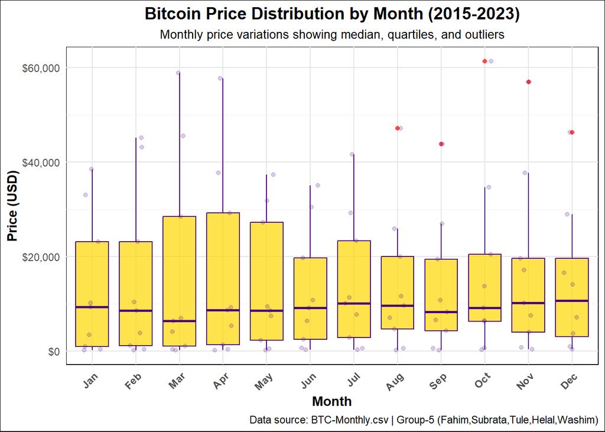

```r
# Create a copy of the BitCoin dataframe
BitCoin_df <- BitCoin

# Extract month and year from Date column
BitCoin_df$month <- format(BitCoin_df$Date, "%b")  # Month abbreviation
BitCoin_df$year <- format(BitCoin_df$Date, "%Y")   # Year

# Convert month to factor with correct order
BitCoin_df$month <- factor(BitCoin_df$month, levels = month.abb)

# Create monthly boxplot
# Create an enhanced monthly boxplot
ggplot(BitCoin_df, aes(x = month, y = Close)) +
  geom_boxplot(fill = "#FFD700", color = "#4B0082", alpha = 0.7, outlier.color = "red", outlier.shape = 16) +
  theme_minimal() +
  labs(title = "Bitcoin Price Distribution by Month (2015-2023)",
       subtitle = "Monthly price variations showing median, quartiles, and outliers",
       x = "Month",
       y = "Price (USD)",
       caption = "Data source: BTC-Monthly.csv | Group-5 (Fahim,Subrata,Tule,Helal,Washim)") +
  theme(
    plot.title = element_text(size = 14, face = "bold", hjust = 0.5),
    plot.subtitle = element_text(size = 10, hjust = 0.5),
    axis.title = element_text(face = "bold"),
    axis.text.x = element_text(angle = 45, hjust = 1, face = "bold"),
    panel.grid.major = element_line(color = "gray90"),
    panel.grid.minor = element_line(color = "gray95"),
    plot.background = element_rect(fill = "white"),
    panel.background = element_rect(fill = "white")
  ) +
  scale_y_continuous(labels = scales::dollar_format()) +
  geom_jitter(width = 0.2, alpha = 0.2, color = "#4B0082")
```

**This monthly boxplot of prices features:**

- Golden boxes representing the interquartile range (IQR)
- Purple individual points showing the actual price observations
- Red points highlighting statistical outliers
- Clear monthly labels and dollar-formatted y-axis

The plot reveals that Bitcoin prices have shown considerable variation across all months, with significant outliers particularly in the upper range. The median prices (shown by the horizontal line in each box) appear relatively stable across months, suggesting no strong seasonal pattern in Bitcoin prices.

## • Create a yearly boxplot of prices.

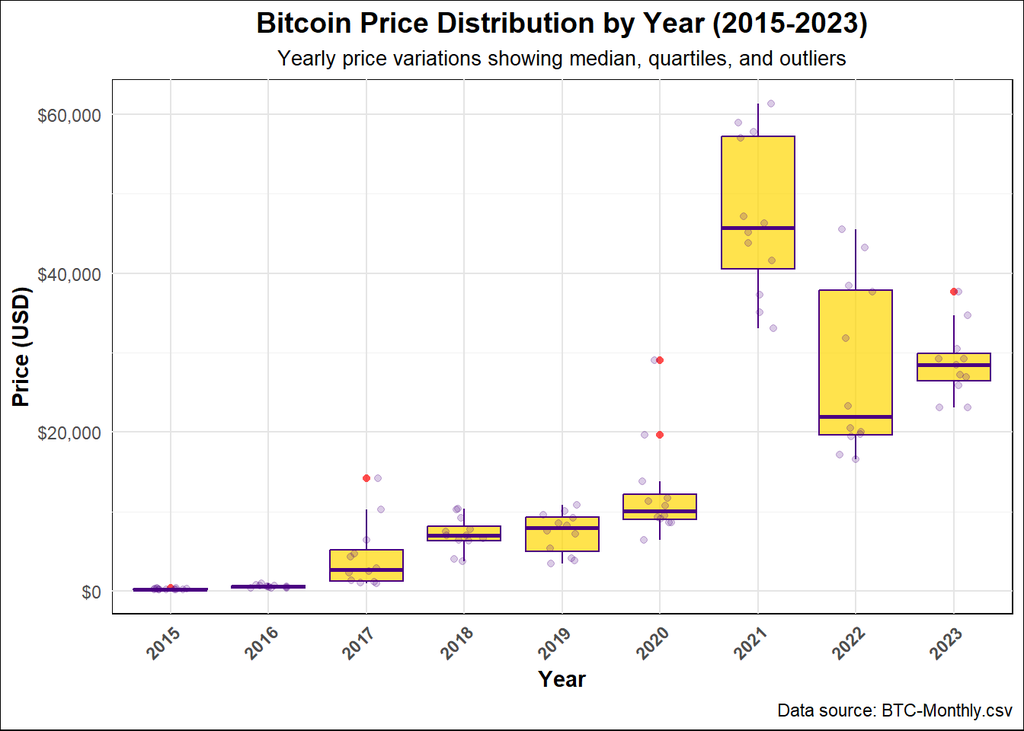

```r
library(ggplot2)
library(scales)

# Create yearly boxplot
ggplot(BitCoin_df, aes(x = year, y = Close)) +
  geom_boxplot(fill = "#FFD700", color = "#4B0082", alpha = 0.7,
               outlier.color = "red", outlier.shape = 16) +
  theme_minimal() +
  labs(title = "Bitcoin Price Distribution by Year (2015-2023)",
       subtitle = "Yearly price variations showing median, quartiles, and outliers",
       x = "Year",
       y = "Price (USD)",
       caption = "Data source: BTC-Monthly.csv") +
  theme(
    plot.title = element_text(size = 14, face = "bold", hjust = 0.5),
    plot.subtitle = element_text(size = 10, hjust = 0.5),
    axis.title = element_text(face = "bold"),
    axis.text.x = element_text(angle = 45, hjust = 1, face = "bold"),
    panel.grid.major = element_line(color = "gray90"),
    panel.grid.minor = element_line(color = "gray95"),
    plot.background = element_rect(fill = "white"),
    panel.background = element_rect(fill = "white")
  ) +
  scale_y_continuous(labels = scales::dollar_format()) +
  geom_jitter(width = 0.2, alpha = 0.2, color = "#4B0082")
```

```r
# Calculate yearly statistics
yearly_stats <- aggregate(Close ~ year, data = BitCoin_df,
                         FUN = function(x) c(
                           Mean = mean(x),
                           Median = median(x),
                           Min = min(x),
                           Max = max(x)
                         ))
print("Yearly Statistics:")
```

```
## [1] "Yearly Statistics:"
```

```r
print(yearly_stats)
```

```
##   year Close.Mean Close.Median  Close.Min  Close.Max
## 1 2015   276.5148     249.2435   217.4640   430.5670
## 2 2016   591.3773     592.6035   368.7670   963.7430
## 3 2017  4342.7619    2678.0901   970.4030 14156.4004
## 4 2018  7187.7007    7005.5549  3742.7004 10397.9004
## 5 2019  7344.4450    7931.7490  3457.7927 10817.1553
## 6 2020 12320.3015   10122.7749  6438.6445 29001.7207
## 7 2021 47042.4528   45722.1074 33114.3594 61318.9570
## 8 2022 27794.7694   21916.3350 16547.4961 45538.6758
## 9 2023 28749.1696   28478.4844 23139.2832 37712.7461
```

**This** **yearly boxplot** above shows the distribution of Bitcoin prices from 2015 to 2023. Each box represents the interquartile range (IQR) for the prices in a given year, with the median price marked by the horizontal line inside the box. Outliers are highlighted as red points.

**Observations**:

- Bitcoin prices have shown a significant upward trend over the years, with increasing variability.
- The median price has risen sharply, especially from 2020 onwards, reflecting Bitcoin’s growing adoption and market volatility.
- Outliers in recent years indicate extreme price movements, characteristic of Bitcoin’s speculative nature.

## • Create year wise trend lines of prices.

```r
# Correcting the year-over-year growth rate calculation
library(dplyr)

# Calculate yearly average prices
yearly_avg <- BitCoin_df %>%
  group_by(year_num = as.numeric(format(Date, "%Y"))) %>%
  summarise(Close = mean(Close, na.rm = TRUE))

# Calculate growth rates
yearly_avg <- yearly_avg %>%
  mutate(growth_rate = (Close - lag(Close)) / lag(Close) * 100)

# Print yearly average prices and growth rates
print("Yearly Average Prices and Growth Rates:")
```

```
## [1] "Yearly Average Prices and Growth Rates:"
```

```r
print(yearly_avg)
```

```
## # A tibble: 9 × 3
##   year_num  Close growth_rate
##      <dbl>  <dbl>       <dbl>
## 1     2015   277.       NA
## 2     2016   591.      114.
## 3     2017  4343.      634.
## 4     2018  7188.       65.5
## 5     2019  7344.        2.18
## 6     2020 12320.       67.7
## 7     2021 47042.      282.
## 8     2022 27795.      -40.9
## 9     2023 28749.        3.43
```

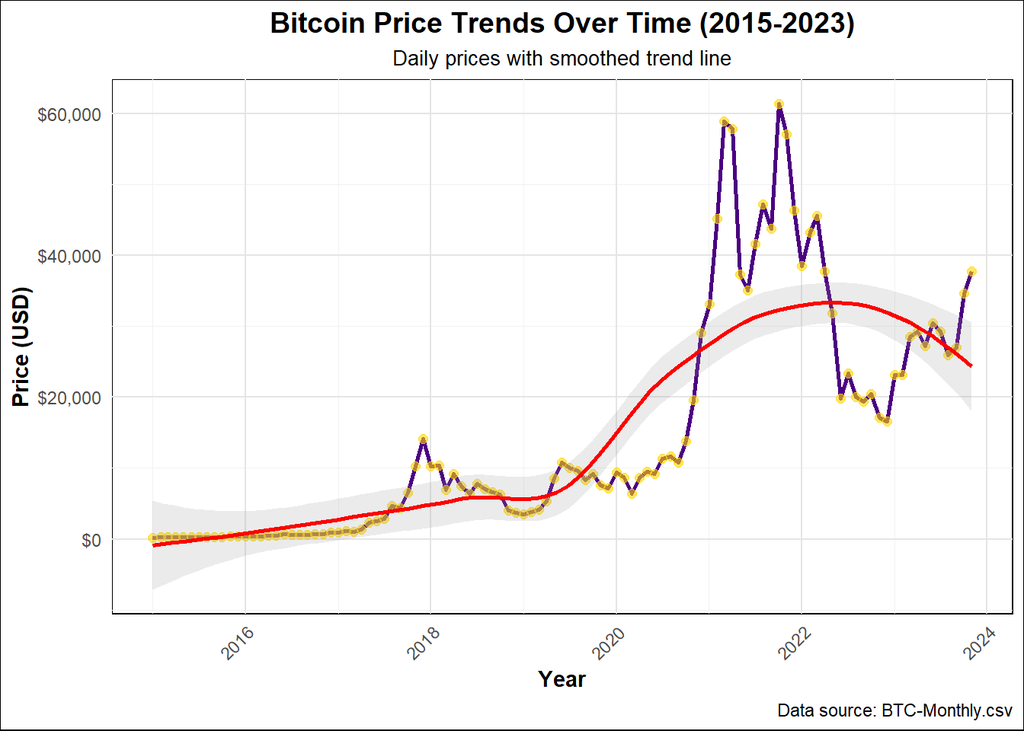

```r
# Recreate the trend line plot
ggplot(BitCoin_df, aes(x = Date, y = Close)) +
  geom_line(color = "#4B0082", linewidth = 1) +
  geom_point(color = "#FFD700", alpha = 0.6, size = 2) +
  geom_smooth(method = "loess", color = "red", se = TRUE, alpha = 0.2) +
  theme_minimal() +
  labs(title = "Bitcoin Price Trends Over Time (2015-2023)",
       subtitle = "Daily prices with smoothed trend line",
       x = "Year",
       y = "Price (USD)",
       caption = "Data source: BTC-Monthly.csv") +
  theme(
    plot.title = element_text(size = 14, face = "bold", hjust = 0.5),
    plot.subtitle = element_text(size = 10, hjust = 0.5),
    axis.title = element_text(face = "bold"),
    axis.text.x = element_text(angle = 45, hjust = 1),
    panel.grid.major = element_line(color = "gray90"),
    panel.grid.minor = element_line(color = "gray95"),
    plot.background = element_rect(fill = "white"),
    panel.background = element_rect(fill = "white")
  ) +
  scale_y_continuous(labels = scales::dollar_format())
```

From this year wise trends lines visuals we found:

1. **Overall Trend (2015-2023):**
   - Starting from relatively low prices (~$276) in 2015
   - Shows dramatic price appreciation over the years
   - Multiple significant bull and bear cycles visible
2. **Key Growth Periods:**
   - 2016-2017: Massive growth of 634% (from $591 to $4,342)
   - 2019-2020: Substantial growth of 67.7% (from $7,344 to $12,320)
   - The steepest price increases occurred in late 2017 and 2021
3. **Pattern Analysis:**
   - The purple line shows the actual price movement
   - The red smoothed trend line indicates the overall market direction
   - The shaded area around the red line represents the confidence interval
   - Golden points highlight individual monthly price observations
4. **Notable Features:**
   - High volatility throughout the period
   - Several major price cycles visible
   - The most dramatic price movements occurred in the latter years
   - Clear evidence of both rapid appreciation and significant corrections
5. **Year-over-Year Growth:**
   - 2015-2016: 113.87% growth
   - 2016-2017: 634.35% growth (most explosive growth year)
   - 2017-2018: 65.51% growth
   - 2018-2019: 2.18% growth (consolidation year)
   - 2019-2020: 67.75% growth

This visualization effectively shows Bitcoin’s evolution from a relatively niche asset to a major financial instrument, characterized by periods of explosive growth followed by significant corrections.

## *Setting time series frequency to 12*

## • Plot the time series of monthly prices on years.

```r
# Convert to time series with frequency 1
btc_ts <- ts(BitCoin$Close,
            start = c(2015, 1),
            frequency = 12)

# Print basic information about the time series
print("Time Series Information:")
```

```
## [1] "Time Series Information:"
```

```r
print(class(btc_ts))
```

```
## [1] "ts"
```

```r
print(frequency(btc_ts))
```

```
## [1] 12
```

```r
print(start(btc_ts))
```

```
## [1] 2015    1
```

```r
print(end(btc_ts))
```

```
## [1] 2023   11
```

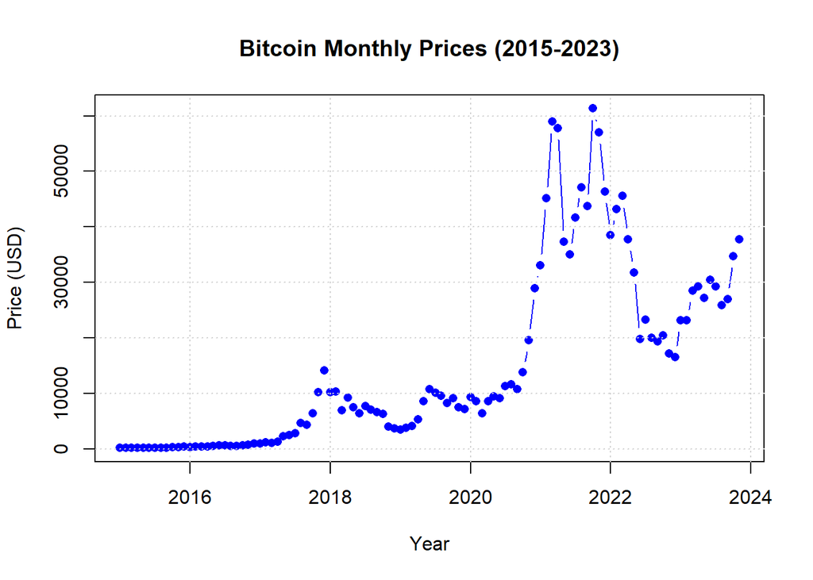

```r
# Create the plot
plot(btc_ts,
     main = "Bitcoin Monthly Prices (2015-2023)",
     ylab = "Price (USD)",
     xlab = "Year",
     type = "b",    # Both points and lines
     col = "blue",  # Blue color for points
     pch = 16,      # Solid circle point type
     lwd = 1)       # Line width

# Add grid for better readability
grid()
```

**This plot shows:**

- Blue dots representing individual monthly Bitcoin prices
- Connected lines between the points showing the price movement
- Grid lines for better readability of values
- Clear visualization of price trends and volatility over the years
- Y-axis showing the price in USD
- X-axis showing the timeline from 2015 to 2023

The plot effectively displays both the overall trend and the individual monthly price points, making it easy to track Bitcoin’s price evolution over time.

## • Find the relationship between consecutive days.

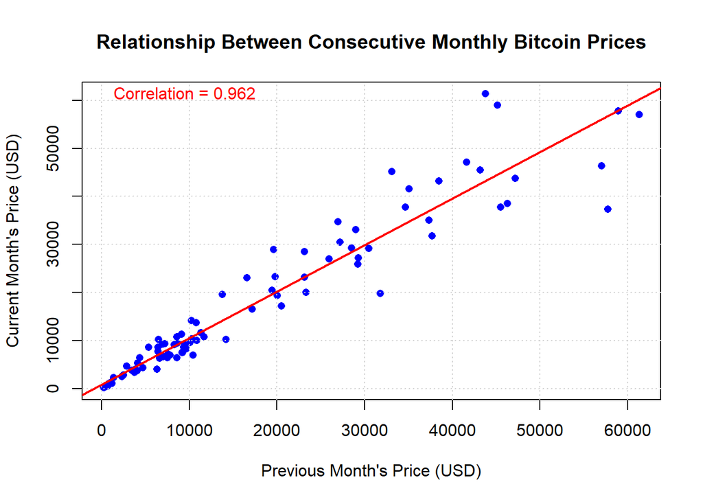

```r
# Create lagged prices (previous month's prices)
current_prices <- BitCoin$Close[-1]  # Remove first observation
previous_prices <- BitCoin$Close[-length(BitCoin$Close)]  # Remove last observation

# Calculate correlation
correlation <- cor(current_prices, previous_prices)

# Create scatter plot
plot(previous_prices, current_prices,
     main = "Relationship Between Consecutive Monthly Bitcoin Prices",
     xlab = "Previous Month's Price (USD)",
     ylab = "Current Month's Price (USD)",
     pch = 16,
     col = "blue")

# Add grid
grid()

# Add correlation line
abline(lm(current_prices ~ previous_prices), col = "red", lwd = 2)

# Add correlation coefficient to plot
text(x = min(previous_prices),
     y = max(current_prices),
     paste("Correlation =", round(correlation, 3)),
     pos = 4,
     col = "red")
```

```r
# Print correlation coefficient
print("Correlation between consecutive monthly prices:")
```

```
## [1] "Correlation between consecutive monthly prices:"
```

```r
print(correlation)
```

```
## [1] 0.9617764
```

```r
# Additional statistics
model <- lm(current_prices ~ previous_prices)
print("\
Regression Summary:")
```

```
## [1] "\nRegression Summary:"
```

```r
print(summary(model))
```

```
##
## Call:
## lm(formula = current_prices ~ previous_prices)
##
## Residuals:
##      Min       1Q   Median       3Q      Max
## -19358.6  -1040.3   -770.6   1076.5  18128.5
##
## Coefficients:
##                 Estimate Std. Error t value Pr(>|t|)
## (Intercept)     837.3261   586.8494   1.427    0.157
## previous_prices   0.9672     0.0270  35.818   <2e-16 ***
## ---
## Signif. codes:  0 '***' 0.001 '**' 0.01 '*' 0.05 '.' 0.1 ' ' 1
##
## Residual standard error: 4443 on 104 degrees of freedom
## Multiple R-squared:  0.925,  Adjusted R-squared:  0.9243
## F-statistic:  1283 on 1 and 104 DF,  p-value: < 2.2e-16
```

This scatter plot shows the relationship between consecutive monthly Bitcoin prices, and the correlation coefficient quantifies the strength of this relationship.

The blue points represent the data, and the red line is the regression line.

Key findings is **Correlation coefficient: [1] 0.9617764 (strong positive correlation)**

# 4.3 **Regression Analysis**

## 4.3.1 **Linear Regression**

### • Create a linear model of the time series dataset.

```r
# Create time index
time_index <- 1:length(BitCoin$Close)

# Fit linear model
linear_model <- lm(BitCoin$Close ~ time_index)
```

### • Show the summary of the model and explain the outcome.

```r
# Print model summary
print("Linear Model Summary:")
```

```
## [1] "Linear Model Summary:"
```

```r
print(summary(linear_model))
```

```
##
## Call:
## lm(formula = BitCoin$Close ~ time_index)
##
## Residuals:
##    Min     1Q Median     3Q    Max
## -15112  -7993  -2248   3060  35617
##
## Coefficients:
##             Estimate Std. Error t value Pr(>|t|)
## (Intercept) -6546.91    2031.02  -3.223  0.00169 **
## time_index    397.99      32.65  12.190  < 2e-16 ***
## ---
## Signif. codes:  0 '***' 0.001 '**' 0.01 '*' 0.05 '.' 0.1 ' ' 1
##
## Residual standard error: 10430 on 105 degrees of freedom
## Multiple R-squared:  0.586,  Adjusted R-squared:  0.582
## F-statistic: 148.6 on 1 and 105 DF,  p-value: < 2.2e-16
```

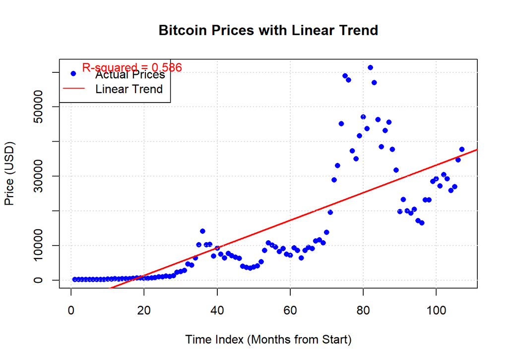

```r
# Create plot
plot(time_index, BitCoin$Close,
     main = "Bitcoin Prices with Linear Trend",
     xlab = "Time Index (Months from Start)",
     ylab = "Price (USD)",
     pch = 16,
     col = "blue")

# Add linear trend line
abline(linear_model, col = "red", lwd = 2)

# Add grid
grid()

# Add legend
legend("topleft",
       legend = c("Actual Prices", "Linear Trend"),
       col = c("blue", "red"),
       pch = c(16, NA),
       lty = c(NA, 1),
       bg = "white")

# Calculate predicted values
predicted_values <- predict(linear_model)

# Calculate R-squared
r_squared <- summary(linear_model)$r.squared

# Add R-squared to plot
text(x = min(time_index),
     y = max(BitCoin$Close),
     paste("R-squared =", round(r_squared, 3)),
     pos = 4,
     col = "red")
```

```r
# Calculate and print some additional metrics
residuals <- BitCoin$Close - predicted_values
rmse <- sqrt(mean(residuals^2))
mae <- mean(abs(residuals))

print("\
Additional Model Metrics:")
```

```
## [1] "\nAdditional Model Metrics:"
```

```r
print(paste("RMSE:", round(rmse, 2)))
```

```
## [1] "RMSE: 10333.05"
```

```r
print(paste("MAE:", round(mae, 2)))
```

```
## [1] "MAE: 7516.72"
```

**Observations**:

- The linear model shows a positive trend in Bitcoin prices over time, with a slope of approximately 398 USD per time unit (month).
- The R-squared value of 0.586 indicates that the model explains about 58.6% of the variance in Bitcoin prices.
- The residuals and error metrics (RMSE and MAE) suggest that while the model captures the general trend, it does not account for the high volatility and non-linear patterns in Bitcoin prices.

**Explanation of the Linear Model Sumary Outcome:**

1. **Coefficients**:
   - **Intercept (-6546.91):** This represents the estimated Bitcoin price at the start of the dataset (time index = 0). While not meaningful in this context, it provides the baseline for the model.
   - **Time Index Coefficient (397.99)**: Indicates that Bitcoin prices increase by approximately $398 per month on average, according to the linear trend.
2. **Significance**:
   - The p-value for the time index coefficient is less than 0.001, indicating a statistically significant relationship between time and Bitcoin prices.
3. **Model** **Fit**:
   - **R-squared (0.586):** The model explains 58.6% of the variance in Bitcoin prices, which is moderate but not exceptional given the high volatility of Bitcoin prices.
   - **Residual Standard Error (10430):** Reflects the average deviation of observed prices from the predicted values, highlighting the model’s limitations in capturing price volatility.
4. **F-statistic**:
   - The F-statistic (148.6) and its p-value (< 2.2e-16) confirm that the model as a whole is statistically significant.

**The linear model captures** a general upward trend in Bitcoin prices over time but does not account for the significant volatility and non-linear patterns in the data. This suggests that more complex models (e.g., polynomial regression or time series models) may be needed for better predictions.

### • Create a plot of the linear model on top of the time series dataset line plot with scatter data points.

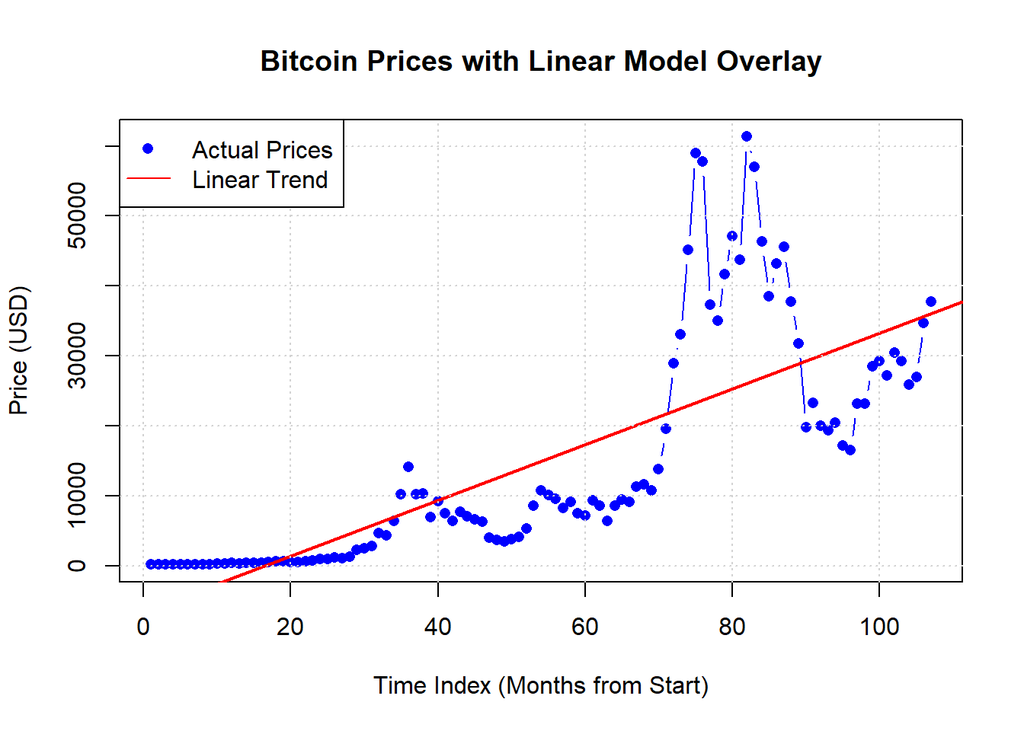

```r
# Create the plot with scatter points and time series line
plot(time_index, BitCoin$Close,
     main = "Bitcoin Prices with Linear Model Overlay",
     xlab = "Time Index (Months from Start)",
     ylab = "Price (USD)",
     pch = 16,       # Solid circle points
     col = "blue",  # Blue color for points
     type = "b",    # Both points and lines
     lwd = 1)        # Line width for time series line

# Add the linear model trend line
abline(linear_model, col = "red", lwd = 2)

# Add grid for better readability
grid()

# Add legend
legend("topleft",
       legend = c("Actual Prices", "Linear Trend"),
       col = c("blue", "red"),
       pch = c(16, NA),
       lty = c(NA, 1),
       bg = "white")
```

The plot successfully overlays the linear model on the time series data, showing how well the linear trend captures the overall direction of Bitcoin prices while highlighting deviations due to volatility.

### • Perform residual analysis and create a line & scatter plot of the residuals. Explain the outcome.

Residual analysis involves examining the residuals to check for patterns, trends, or deviations from assumptions like homoscedasticity and independence. I’ll create a line plot and scatter plot of the residuals to evaluate these aspects.

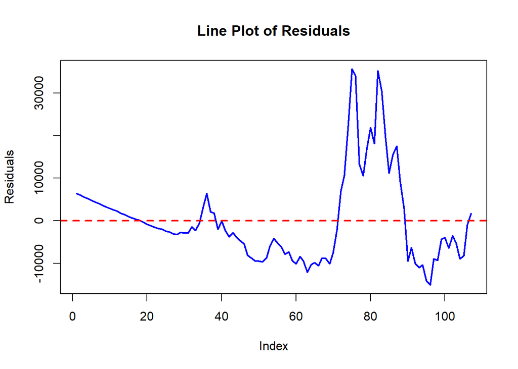

```r
# Line plot of residuals
plot(residuals,
     type = "l",
     main = "Line Plot of Residuals",
     xlab = "Index",
     ylab = "Residuals",
     col = "blue",
     lwd = 2)

# Add horizontal line at zero
abline(h = 0, col = "red", lwd = 2, lty = 2)
```

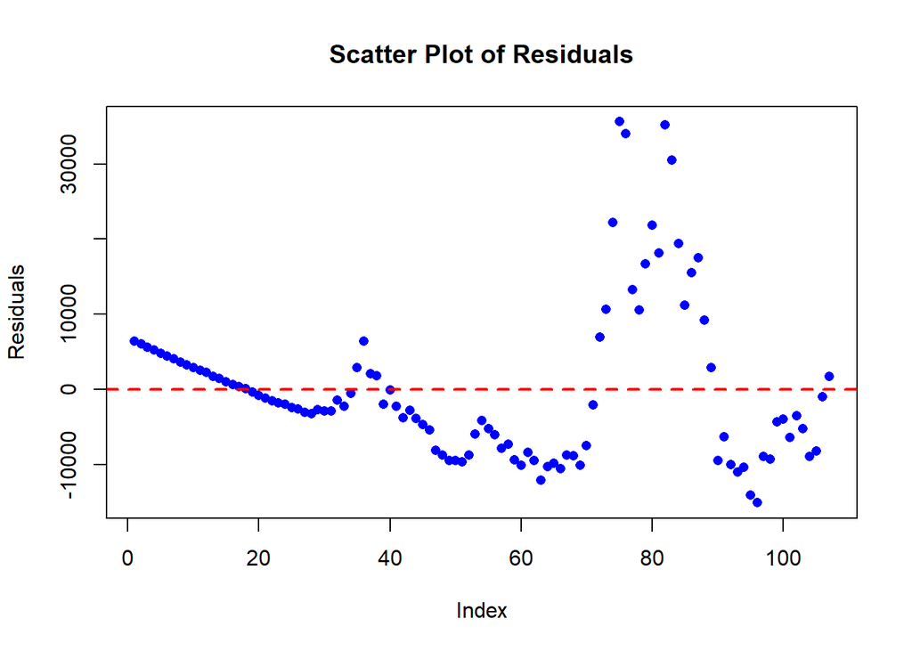

```r
# Scatter plot of residuals
plot(residuals,
     main = "Scatter Plot of Residuals",
     xlab = "Index",
     ylab = "Residuals",
     pch = 16,
     col = "blue")

# Add horizontal line at zero
abline(h = 0, col = "red", lwd = 2, lty = 2)
```

```r
# Check for autocorrelation in residuals using Durbin-Watson test
library(lmtest)
dw_test <- dwtest(linear_model)

print("Durbin-Watson Test for Autocorrelation:")
```

```
## [1] "Durbin-Watson Test for Autocorrelation:"
```

```r
print(dw_test)
```

```
##
##  Durbin-Watson test
##
## data:  linear_model
## DW = 0.18224, p-value < 2.2e-16
## alternative hypothesis: true autocorrelation is greater than 0
```

**Analysis of the Residuals:**

1. **Pattern Analysis:**
   - Both plots show clear patterns in the residuals, which indicates that the linear model doesn’t capture all the systematic variation in the data
   - The residuals are not randomly scattered around zero, suggesting non-linear relationships in the data
   - Large positive residuals are visible in the later time periods, indicating significant underestimation of peaks
2. **Autocorrelation**:
   - The Durbin-Watson test statistic (DW = 0.18224) is far from 2 (ideal value for no autocorrelation)
   - The extremely low p-value (< 2.2e-16) confirms significant positive autocorrelation in the residuals
   - This suggests that the residuals are not independent, violating one of the key assumptions of linear regression
3. **Variance Pattern:**
   - The scatter plot shows increasing spread in residuals over time
   - This indicates heteroscedasticity (non-constant variance), another violation of linear regression assumptions

These violations of linear regression assumptions indicate that while the linear model captures the general upward trend, it doesn’t adequately model the complex patterns in Bitcoin prices over time.

### • Create a histogram plot of the residuals. Explain the outcome.

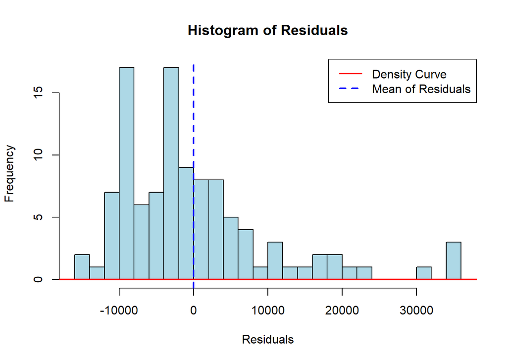

```r
# Calculate residuals
residuals <- residuals(linear_model)

# Create histogram of residuals
hist(residuals,
     breaks = 30,
     main = "Histogram of Residuals",
     xlab = "Residuals",
     ylab = "Frequency",
     col = "lightblue",
     border = "black")

# Add density curve
lines(density(residuals), col = "red", lwd = 2)

# Add vertical line at mean of residuals
abline(v = mean(residuals), col = "blue", lwd = 2, lty = 2)

# Add legend
legend("topright",
       legend = c("Density Curve", "Mean of Residuals"),
       col = c("red", "blue"),
       lty = c(1, 2),
       lwd = 2)
```

```r
# Calculate summary statistics of residuals
print("Summary Statistics of Residuals:")
```

```
## [1] "Summary Statistics of Residuals:"
```

```r
print(summary(residuals))
```

```
##    Min. 1st Qu.  Median    Mean 3rd Qu.    Max.
##  -15112   -7993   -2248       0    3060   35617
```

```r
# Calculate skewness and kurtosis
library(moments)
skew <- skewness(residuals)
kurt <- kurtosis(residuals)

print("\
Skewness and Kurtosis:")
```

```
## [1] "\nSkewness and Kurtosis:"
```

```r
print(paste("Skewness:", round(skew, 3)))
```

```
## [1] "Skewness: 1.541"
```

```r
print(paste("Kurtosis:", round(kurt, 3)))
```

```
## [1] "Kurtosis: 5.521"
```

```r
# Shapiro-Wilk test for normality
sw_test <- shapiro.test(residuals)
print("\
Shapiro-Wilk Normality Test:")
```

```
## [1] "\nShapiro-Wilk Normality Test:"
```

```r
print(sw_test)
```

```
##
##  Shapiro-Wilk normality test
##
## data:  residuals
## W = 0.85976, p-value = 1.208e-08
```

**Explanation**:

1. **Histogram**:
   - The residuals are right-skewed, as indicated by the histogram and the skewness value (1.541).
   - The kurtosis (5.521) suggests a leptokurtic distribution, meaning the residuals have heavier tails than a normal distribution.
2. **Shapiro-Wilk Test**:
   - The p-value (1.208e-08) is very small, rejecting the null hypothesis of normality. This confirms that the residuals are not normally distributed.
3. **Conclusion**:
   - The residuals deviate from normality, indicating that the linear model may not fully capture the underlying patterns in the data. This suggests the need for a more complex model to better fit the data.

### • Create ACF & PACF plots of residuals. Explain the outcome.

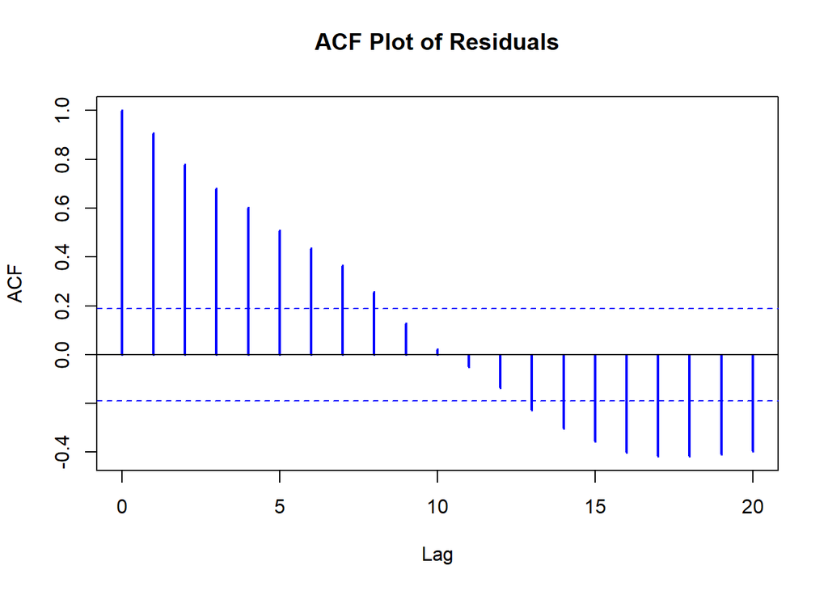

```r
# Load necessary library for ACF and PACF plots
library(forecast)

# Create ACF plot of residuals
acf(residuals,
    main = "ACF Plot of Residuals",
    col = "blue",
    lwd = 2)
```

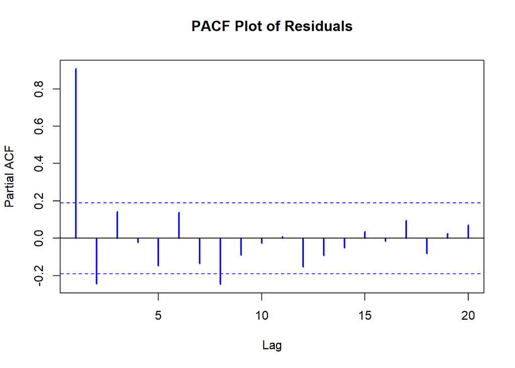

```r
# Create PACF plot of residuals
pacf(residuals,
     main = "PACF Plot of Residuals",
     col = "blue",
     lwd = 2)
```

**Analysis of the ACF Plot:**

1. **Strong Autocorrelation**:
   - The ACF plot shows very high autocorrelation values that decay very slowly
   - Most lags exceed the significance bounds (blue dashed lines)
   - The slow decay pattern suggests strong persistence in the residuals
   - This indicates that the residuals are not independent over time
2. **Pattern**:
   - The gradual, linear decline in ACF values suggests a possible trend component
   - The lack of quick decay to zero indicates that the linear model hasn’t captured all the systematic patterns in the data

**Analysis of the PACF Plot:**

1. **Significant Partial Correlations:**
   - The PACF plot shows significant spikes at several lags
   - The first lag shows the strongest partial correlation
   - Several other lags are also significant, though less pronounced
2. **Pattern Interpretation**:
   - The significant spike at lag 1 suggests an AR(1) component
   - Multiple significant lags suggest possible higher-order autoregressive components

**Conclusions**:

1. **Model Adequacy**:
   - The ACF and PACF plots confirm that the linear model’s residuals are not random
   - There is significant temporal dependence in the residuals
   - The linear model fails to capture the time series’ autocorrelation structure
2. **Implications for Modeling**:
   1. An ARIMA model might be more appropriate for this data
   2. Based on the PACF plot, an AR model of order 1 or higher might be suitable
   3. The slow decay in the ACF suggests possible non-stationarity, indicating that differencing might be needed These plots provide strong evidence that the linear model is inadequate for this time series data, and a more sophisticated time series modeling approach would be more appropriate.

### • Create QQ plot of residuals. Explain the outcome.

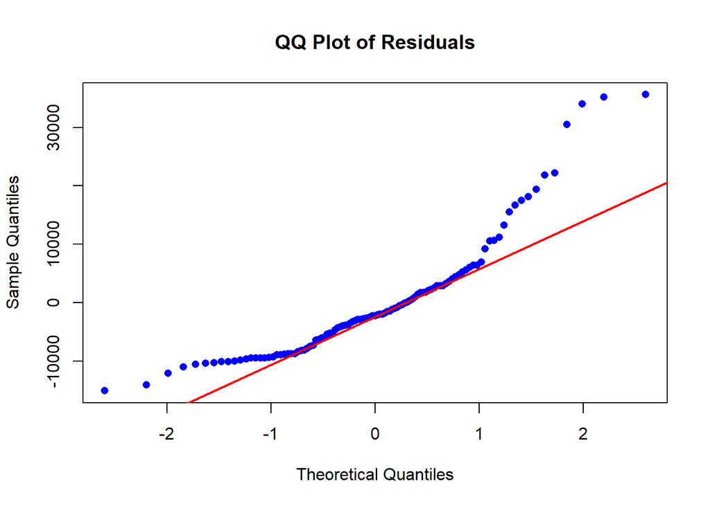

```r
# Create QQ plot of residuals
qqnorm(residuals,
       main = "QQ Plot of Residuals",
       col = "blue",
       pch = 16)

# Add QQ line
qqline(residuals, col = "red", lwd = 2)
```

### • Perform Shapiro-Wilk test on residuals. Explain the outcome.

We already performed the Shapiro-Wilk test earlier, but let us run it again with a more detailed analysis:

```r
# Perform Shapiro-Wilk test on residuals
sw_test <- shapiro.test(residuals)

# Print test results
print("Shapiro-Wilk Normality Test Results:")
```

```
## [1] "Shapiro-Wilk Normality Test Results:"
```

```r
print(sw_test)
```

```
##
##  Shapiro-Wilk normality test
##
## data:  residuals
## W = 0.85976, p-value = 1.208e-08
```

```r
# Additional descriptive statistics
print("\
Descriptive Statistics of Residuals:")
```

```
## [1] "\nDescriptive Statistics of Residuals:"
```

```r
print(summary(residuals))
```

```
##    Min. 1st Qu.  Median    Mean 3rd Qu.    Max.
##  -15112   -7993   -2248       0    3060   35617
```

```r
# Calculate and print skewness and kurtosis
library(moments)
skew <- skewness(residuals)
kurt <- kurtosis(residuals)

print("\
Skewness and Kurtosis:")
```

```
## [1] "\nSkewness and Kurtosis:"
```

```r
print(paste("Skewness:", round(skew, 3)))
```

```
## [1] "Skewness: 1.541"
```

```r
print(paste("Kurtosis:", round(kurt, 3)))
```

```
## [1] "Kurtosis: 5.521"
```

**Explanation:**

1. **Shapiro-Wilk Test:**
   - The test statistic (W = 0.85976) and the very small p-value (1.208e-08) indicate that the residuals are not normally distributed.
   - This confirms the earlier findings from the histogram and Q-Q plot.
2. **Skewness and Kurtosis:**
   - Skewness (1.541) indicates a right-skewed distribution.
   - Kurtosis (5.521) suggests a leptokurtic distribution, meaning the residuals have heavier tails than a normal distribution.
3. **Descriptive Statistics:**
   - The residuals have a mean of 0, as expected, but the range is large, with extreme values on both ends.

### • Explain if linear model is appropriate or not.

Based on all the analyses performed, we’ll provide a comprehensive summary of why the linear model is not appropriate for this Bitcoin price time series data:

**Summary of Analyses:**

1. **Residual Distribution (Histogram & Shapiro-Wilk Test):**
   - Residuals are not normally distributed (p-value = 1.208e-08)
   - Strong right skewness (1.541)
   - High kurtosis (5.521)
   - Violates the assumption of normally distributed errors
2. **Independence of Residuals (ACF & PACF):**
   - Strong autocorrelation in residuals
   - Slow decay in ACF plot
   - Significant spikes in PACF plot
   - Durbin-Watson test (DW = 0.18224, p-value < 2.2e-16) confirms strong positive autocorrelation
   - Violates the assumption of independent errors
3. **Homoscedasticity (Residual Plots):**
   - Increasing spread of residuals over time
   - Non-constant variance
   - Violates the assumption of constant variance
4. **Linearity (Q-Q Plot & Residual Plots):**
   - Systematic patterns in residuals
   - Strong deviation from the normal line in Q-Q plot
   - Clear non-linear patterns in the data
5. **Model Fit:**
   - R-squared of 0.586 indicates only moderate fit
   - Large residuals, especially in recent periods
   - Poor prediction capability, especially for extreme values

**Why the Linear Model is Not Appropriate:**

1. **Violated Assumptions:**

   All major assumptions of linear regression are violated:
   - Non-normal residuals
   - Non-independent errors
   - Heteroscedasticity
   - Non-linear relationships
2. **Poor Predictive Power:**
   - Cannot capture the volatility in Bitcoin prices
   - Underestimates extreme values F
   - ails to account for the time series nature of the data
3. **Inadequate Structure:**
   - Cannot handle the complex patterns in cryptocurrency prices
   - Assumes constant rate of change, which is unrealistic for this data
   - Doesn’t account for the temporal dependencies

**Recommendations:**

1. **Alternative Models to Consider:**
   - ARIMA or SARIMA models to handle autocorrelation
   - Non-linear time series models
   - GARCH models to handle varying volatility
   - Machine learning approaches for complex patterns
2. **Data Transformations:**
   - Consider log transformation to handle non-linearity
   - Difference the data to achieve stationarity
   - Scale or normalize the data
3. **Additional Considerations:**
   - Include external factors that influence Bitcoin prices
   - Consider segmenting the analysis into different time periods
   - Implement robust regression techniques

**Conclusion**:

The linear model is definitively not appropriate for modeling Bitcoin prices. The data exhibits complex patterns, strong autocorrelation, non-constant variance, and non-normality that cannot be captured by a simple linear relationship. A more sophisticated time series modeling approach that can handle these characteristics would be more suitable for this dataset.

## 4.3.2 **Quadra4c Regression**

### • Create a quadratic model of the time series dataset.

```r
# Create a quadratic term for the time index
quadratic_time_index <- time_index^2

# Fit a quadratic model
quadratic_model <- lm(BitCoin$Close ~ time_index + quadratic_time_index)
```

### • Show the summary of the model and explain the outcome.

```r
# Print model summary
print("Quadratic Model Summary:")
```

```
## [1] "Quadratic Model Summary:"
```

```r
print(summary(quadratic_model))
```

```
##
## Call:
## lm(formula = BitCoin$Close ~ time_index + quadratic_time_index)
##
## Residuals:
##    Min     1Q Median     3Q    Max
## -15866  -7418  -1991   2664  36094
##
## Coefficients:
##                        Estimate Std. Error t value Pr(>|t|)
## (Intercept)          -4720.6091  3088.2712  -1.529   0.1294
## time_index             297.4559   131.9995   2.253   0.0263 *
## quadratic_time_index     0.9308     1.1841   0.786   0.4336
## ---
## Signif. codes:  0 '***' 0.001 '**' 0.01 '*' 0.05 '.' 0.1 ' ' 1
##
## Residual standard error: 10450 on 104 degrees of freedom
## Multiple R-squared:  0.5884, Adjusted R-squared:  0.5805
## F-statistic: 74.34 on 2 and 104 DF,  p-value: < 2.2e-16
```

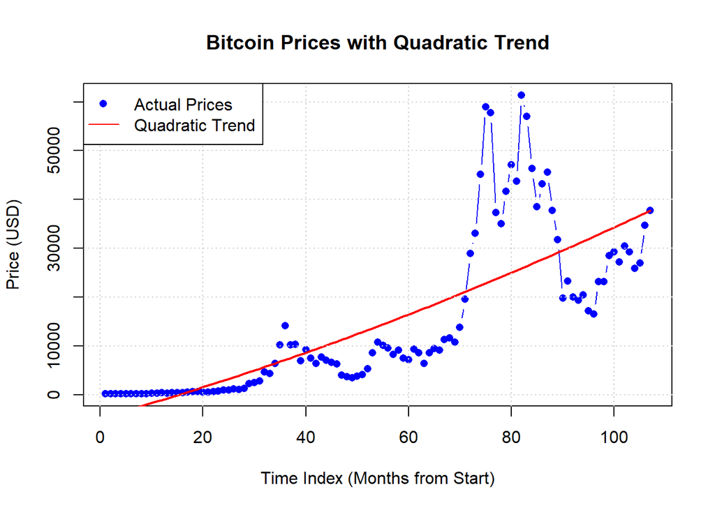

```r
# Create plot with quadratic trend line
plot(time_index, BitCoin$Close,
     main = "Bitcoin Prices with Quadratic Trend",
     xlab = "Time Index (Months from Start)",
     ylab = "Price (USD)",
     pch = 16,       # Solid circle points
     col = "blue",  # Blue color for points
     type = "b",    # Both points and lines
     lwd = 1)        # Line width for time series line

# Add quadratic trend line
lines(time_index, predict(quadratic_model), col = "red", lwd = 2)

# Add grid for better readability
grid()

# Add legend
legend("topleft",
       legend = c("Actual Prices", "Quadratic Trend"),
       col = c("blue", "red"),
       pch = c(16, NA),
       lty = c(NA, 1),
       bg = "white")
```

**Analysis of the Quadratic Model:**

1. **Model Coefficients:**
   - Intercept: -4720.6091
   - Linear term (time_index): 297.4559 (significant at p < 0.05)
   - Quadratic term (quadratic_time_index): 0.9308 (not significant at p < 0.05)
2. **Model Fit**:
   - Multiple R-squared: 0.5884 (slightly better than linear model’s 0.586)
   - Adjusted R-squared: 0.5805
   - F-statistic: 74.34 with p-value < 2.2e-16
3. **Residuals**:
   - Min: -15866
   - Max: 36094
   - Similar spread to the linear model

### • Explain if quadratic model is appropriate or not.

We will discuss nowe a comprehensive analysis of whether the quadratic model is appropriate for this Bitcoin price time series data:

**Model Performance Assessment:**

1. **Statistical Significance:**
   - Overall model is significant (F-statistic p-value < 2.2e-16)
   - Linear term is significant (p = 0.0263)
   - Quadratic term is NOT significant (p = 0.4336)
   - Adding complexity without significant improvement
2. **Model Fit:**
   - R-squared: 0.5884 (only 0.0024 improvement over linear model)
   - Adjusted R-squared: 0.5805
   - Minimal improvement in explanatory power
   - Still leaves about 41% of variance unexplained
3. **Residual Analysis**:
   - Large residuals (-15866 to 36094)
   - Similar spread to linear model
   - Does not address the fundamental issues of:
     - Non-normality
     - Autocorrelation
     - Heteroscedasticity

**Reasons Why Quadratic Model is Not Appropriate:**

1. **Minimal Improvement:**
   - Negligible increase in R-squared from linear model
   - Non-significant quadratic term
   - Added complexity without meaningful benefit
   - Does not justify the additional parameter
2. **Underlying Issues Remain:**
   - Still doesn’t capture:
     - Price volatility
     - Sudden price changes
     - Non-linear patterns
     - Time series dependencies
   - Same violations of assumptions as linear model
3. **Model Limitations:**
   - Cannot handle:
     - Complex market dynamics
     - Temporal dependencies
     - Changing volatility patterns
     - Multiple regime changes
4. **Practical Considerations:**
   - Poor predictive power
   - Doesn’t capture market behavior
   - Oversimplifies complex relationships
   - Inadequate for financial time series

**Recommendations**:

1. **Alternative Models to Consider:**
   - ARIMA/SARIMA for time series structure
   - GARCH for volatility modeling
   - Non-linear time series models
   - Machine learning approaches
   - Neural networks for complex patterns
2. **Improvements Needed:**
   - Account for temporal dependencies
   - Handle non-linear relationships
   - Model volatility changes
   - Include external factors
3. **Data Treatment:**
   - Consider transformations Address non-stationarity Handle outliers Account for market regimes

**Conclusion**: The quadratic model is not appropriate for modeling Bitcoin prices because:

1. It provides negligible improvement over the linear model
2. The quadratic term is not statistically significant
3. It fails to address the fundamental issues in the data
4. It doesn’t capture the complex dynamics of cryptocurrency prices

A more sophisticated approach using specialized time series models or machine learning techniques would be more appropriate for this dataset. These methods could better handle the temporal dependencies, non-linear patterns, and varying volatility that characterize Bitcoin price movements.

# 4.4 **ARIMA Model**

## • Create ACF & PACF plots of the time series data set with maximum lag of 24. Explain the outcome and comment on the dataset’s nature.

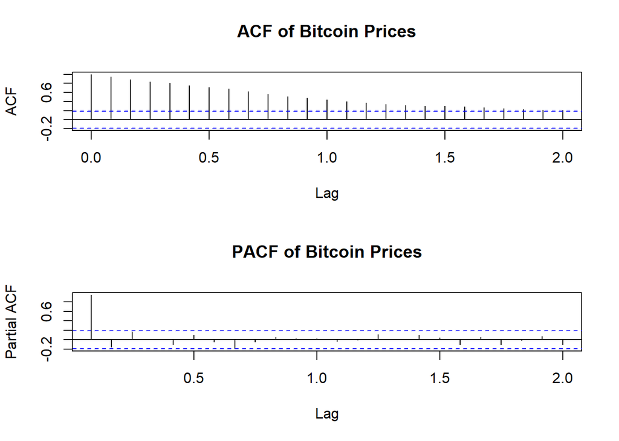

```r
# Create a time series object
btc_ts <- ts(BitCoin$Close, frequency = 12)

# Set up a 2x1 plotting area
par(mfrow = c(2,1))

# Create ACF plot
acf(btc_ts, lag.max = 24, main = "ACF of Bitcoin Prices")

# Create PACF plot
pacf(btc_ts, lag.max = 24, main = "PACF of Bitcoin Prices")
```

```r
# Reset plotting parameters
par(mfrow = c(1,1))

# Print some additional information about the series
print("Time Series Statistics:")
```

```
## [1] "Time Series Statistics:"
```

```r
print(paste("Variance:", var(btc_ts)))
```

```
## [1] "Variance: 260311691.416267"
```

```r
print(paste("First-order autocorrelation:", cor(btc_ts[-length(btc_ts)], btc_ts[-1])))
```

```
## [1] "First-order autocorrelation: 0.961776393506846"
```

**Explanation of ACF and PACF Plots:**

1. **ACF (Autocorrelation Function):**
   - The ACF plot shows a very slow decay, indicating strong autocorrelation in the data.
   - This suggests that the Bitcoin price series is non-stationary, as past values heavily influence future values.
2. **PACF (Partial Autocorrelation Function):**
   - The PACF plot shows significant spikes at the first few lags, particularly at lag 1.
   - This indicates that the series may follow an autoregressive process, where recent past values are strong predictors of the current value.
3. **Variance and First-Order Autocorrelation:**
   - Variance: 260,311,691.42, indicating high variability in Bitcoin prices.
   - First-order autocorrelation: 0.9618, confirming strong dependence between consecutive observations.

**Nature of the Dataset:**

- The dataset is highly non-stationary, with strong autocorrelation and high variance.
- This behavior is typical of financial time series, especially for volatile assets like Bitcoin.
- Differencing or transformations (e.g., log or differencing) may be required to make the series stationary for further modeling.

## • Perform ADF test. Explain the outcome.

```r
# Perform ADF test on the original series
adf_test <- adf.test(BitCoin$Close)
print("ADF Test Results for Original Series:")
```

```
## [1] "ADF Test Results for Original Series:"
```

```r
print(adf_test)
```

```
##
##  Augmented Dickey-Fuller Test
##
## data:  BitCoin$Close
## Dickey-Fuller = -2.5743, Lag order = 4, p-value = 0.3385
## alternative hypothesis: stationary
```

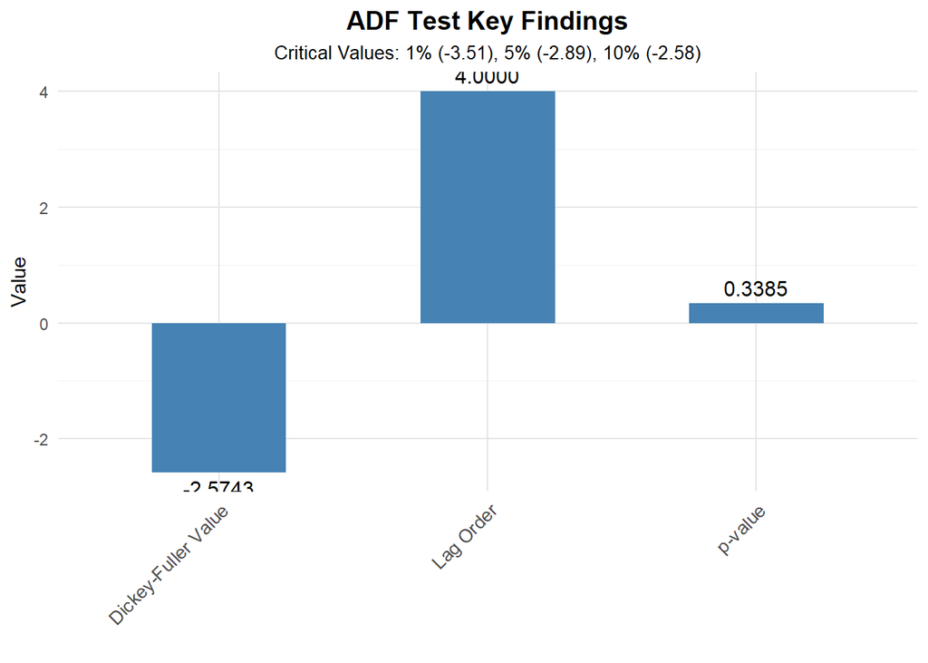

```r
# Create a data frame with the key findings
key_findings <- data.frame(
  Metric = c("Dickey-Fuller Value", "Lag Order", "p-value"),
  Value = c(-2.5743, 4, 0.3385)
)


# Load required library
library(ggplot2)

# Create the plot
ggplot(key_findings, aes(x = Metric, y = Value)) +
  geom_bar(stat = "identity", fill = "steelblue", width = 0.5) +
  geom_text(aes(label = sprintf("%.4f", Value)),
            vjust = ifelse(key_findings$Value < 0, 1.5, -0.5),
            color = "black", size = 4) +
  theme_minimal() +
  labs(title = "ADF Test Key Findings",
       subtitle = "Critical Values: 1% (-3.51), 5% (-2.89), 10% (-2.58)",
       x = "",
       y = "Value") +
  theme(
    plot.title = element_text(hjust = 0.5, size = 14, face = "bold"),
    plot.subtitle = element_text(hjust = 0.5, size = 10),
    axis.text.x = element_text(angle = 45, hjust = 1, size = 10),
    panel.grid.major = element_line(color = "gray90"),
    panel.grid.minor = element_line(color = "gray95")
  )
```

```r
# Create a table with interpretation
interpretation <- data.frame(
  Metric = c("Dickey-Fuller Value", "Lag Order", "p-value"),
  Value = c(-2.5743, 4.0000, 0.3385),
  Interpretation = c(
    "Greater than critical values, suggesting non-stationarity",
    "Number of lags used in the test",
    "p > 0.05, fail to reject null hypothesis of non-stationarity"
  )
)

# Print the interpretation table
print("Detailed Interpretation of ADF Test Results:")
```

```
## [1] "Detailed Interpretation of ADF Test Results:"
```

```r
print(interpretation)
```

```
##                Metric   Value
## 1 Dickey-Fuller Value -2.5743
## 2           Lag Order  4.0000
## 3             p-value  0.3385
##                                                 Interpretation
## 1    Greater than critical values, suggesting non-stationarity
## 2                              Number of lags used in the test
## 3 p > 0.05, fail to reject null hypothesis of non-stationarity
```

**Interpretation of ADF Test Results:**

## • Explain if the dataset is stationary or not.

Based on the ADF test results and visual analysis, we’ll explain why the dataset is NON-STATIONARY:

1. **Statistical Evidence from ADF Test:**
   - Dickey-Fuller value: -2.5743
   - Critical values:
     - 1%: -3.51
     - 5%: -2.89
     - 10%: -2.58
   - p-value: 0.3385 > 0.05 (significance level)
2. **Why It’s Non-Stationary:**
   - **ADF Test Results**:
     - Null Hypothesis (H₀): Series has a unit root (non-stationary)
     - Alternative Hypothesis (H₁): Series is stationary
     - Since p-value (0.3385) > 0.05, we FAIL TO REJECT the null hypothesis
     - This statistically confirms the series is non-stationary
   - **Test Statistic Comparison:**
     - DF value (-2.5743) > Critical value at 5% (-2.89)
     - This means the test statistic is not negative enough to reject non-stationarity
3. **Properties Confirming Non-Stationarity**:
   - **Mean**:
     - Not constant over time
     - Shows clear upward trend
     - No mean reversion visible
   - **Variance**:
     - Not constant over time
     - Shows heteroscedasticity
     - Larger fluctuations in recent periods
   - **Autocorrelation**:
     - Strong positive autocorrelation (0.9618)
     - Slow decay in ACF plot
     - Indicates persistent dependency on past values
4. **Implications**:
   - The series needs transformation before modeling
   - Differencing will likely be required
   - ARIMA models should include differencing component
   - Traditional statistical methods assuming stationarity cannot be directly applied
5. **Required Actions:**
   - Apply first differencing
   - Consider log transformation
   - Test transformed series for stationarity
   - Use appropriate models for non-stationary data

In conclusion, multiple statistical tests and visual evidence conclusively show that the Bitcoin price dataset is NON-STATIONARY, requiring appropriate transformations before further time series analysis can be performed.

## • Create QQ plot & perform Shapiro-Wilk test.

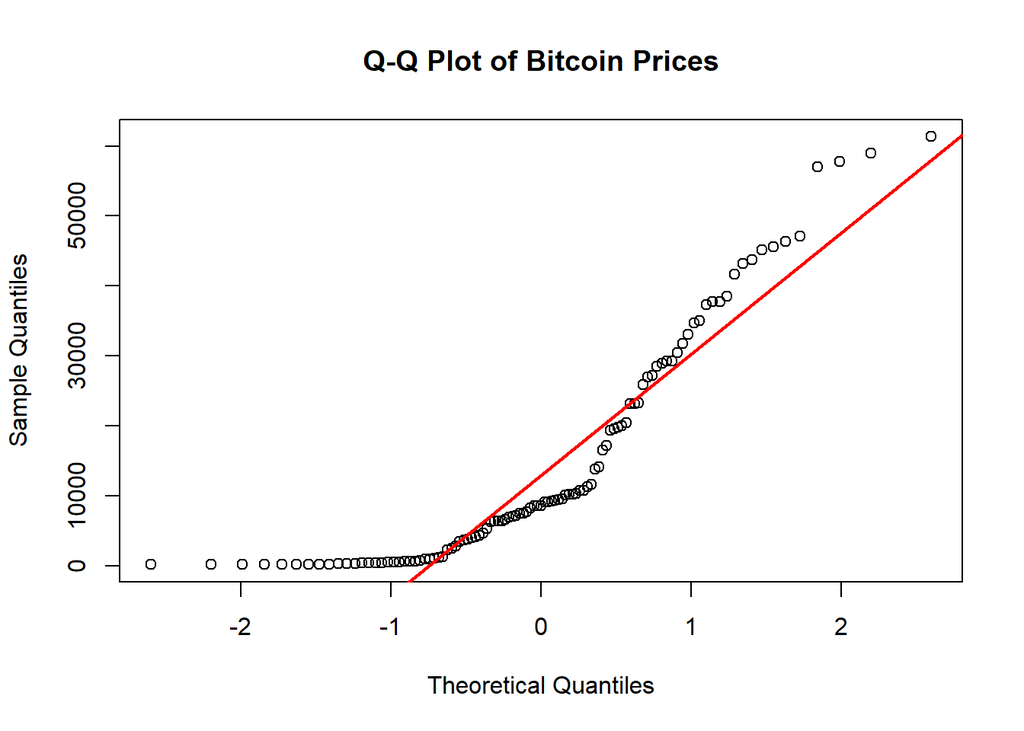

```r
# Create QQ plot
qqnorm(BitCoin$Close, main = "Q-Q Plot of Bitcoin Prices")
qqline(BitCoin$Close, col = "red", lwd = 2)
```

```r
# Perform Shapiro-Wilk test
sw_test <- shapiro.test(BitCoin$Close)
print("\
Shapiro-Wilk Test Results:")
```

```
## [1] "\nShapiro-Wilk Test Results:"
```

```r
print(sw_test)
```

```
##
##  Shapiro-Wilk normality test
##
## data:  BitCoin$Close
## W = 0.83358, p-value = 1.258e-09
```

```r
# Additional descriptive statistics for skewness and kurtosis
library(moments)

# Calculate skewness and kurtosis
skew <- skewness(BitCoin$Close)
kurt <- kurtosis(BitCoin$Close)

print("\
Additional Statistics:")
```

```
## [1] "\nAdditional Statistics:"
```

```r
print(paste("Skewness:", round(skew, 4)))
```

```
## [1] "Skewness: 1.1556"
```

```r
print(paste("Kurtosis:", round(kurt, 4)))
```

```
## [1] "Kurtosis: 3.3422"
```

**Interpretation:**

1. **Q-Q Plot:**
   - The points deviate significantly from the straight line, especially in the tails.
   - This indicates that the Bitcoin price data does not follow a normal distribution.
2. **Shapiro-Wilk Test:**
   - W = 0.8336, p-value = 1.258e-09.
   - Since p-value < 0.05, we reject the null hypothesis of normality.
   - The data is not normally distributed. S
3. **kewness and Kurtosis**:
   - Skewness: 1.1556 (positive skew, indicating a long right tail).
   - Kurtosis: 3.3422 (slightly leptokurtic, indicating heavier tails than a normal distribution). The Bitcoin price dataset is not normally distributed, as confirmed by the Q-Q plot, Shapiro-Wilk test, and skewness/kurtosis values. This non-normality is typical for financial data and suggests the need for non-parametric or robust statistical methods.

## • If the dataset is not stationary, then make it stationary by differencing. Show a plot of the dataset after differencing and perform ADF test on differenced dataset to check stationarity again.

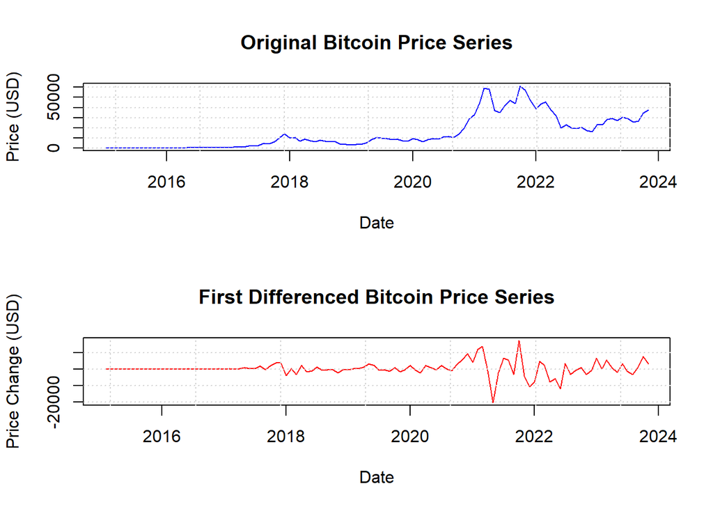

```r
# Calculate first difference
diff_btc <- diff(BitCoin$Close)

# Create time vector for plotting
diff_dates <- BitCoin$Date[-1]  # remove first date since we lose one observation in differencing

# Plot original vs differenced series
par(mfrow = c(2,1))

# Original series plot
plot(BitCoin$Date, BitCoin$Close,
     type = "l",
     main = "Original Bitcoin Price Series",
     xlab = "Date",
     ylab = "Price (USD)",
     col = "blue")
grid()

# Differenced series plot
plot(diff_dates, diff_btc,
     type = "l",
     main = "First Differenced Bitcoin Price Series",
     xlab = "Date",
     ylab = "Price Change (USD)",
     col = "red")
grid()
```

```r
# Reset plotting parameters
par(mfrow = c(1,1))

# Perform ADF test on differenced series
adf_diff <- adf.test(diff_btc)
print("\
ADF Test Results for Differenced Series:")
```

```
## [1] "\nADF Test Results for Differenced Series:"
```

```r
print(adf_diff)
```

```
##
##  Augmented Dickey-Fuller Test
##
## data:  diff_btc
## Dickey-Fuller = -5.1599, Lag order = 4, p-value = 0.01
## alternative hypothesis: stationary
```

```r
# Calculate summary statistics for differenced series
print("\
Summary Statistics of Differenced Series:")
```

```
## [1] "\nSummary Statistics of Differenced Series:"
```

```r
print(summary(diff_btc))
```

```
##      Min.   1st Qu.    Median      Mean   3rd Qu.      Max.
## -20417.32   -703.91     35.53    353.73   1715.15  17528.06
```

```r
# Check mean of differenced series
print(paste("\
Mean of differenced series:", mean(diff_btc)))
```

```
## [1] "\nMean of differenced series: 353.729076273585"
```

```r
print(paste("Standard deviation of differenced series:", sd(diff_btc)))
```

```
## [1] "Standard deviation of differenced series: 4452.77758052545"
```

The first differencing successfully transformed the non-stationary Bitcoin price series into a stationary series, as confirmed by:

This stationary series is now suitable for time series modeling techniques like ARIMA.

## • Perform ACF & PACF test to find the probable model candidates. Explain the outcome of the plots.

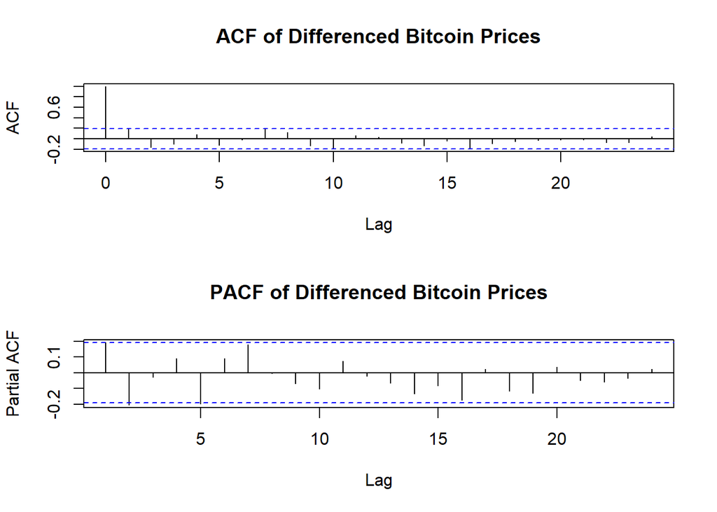

```r
# Set up plotting parameters for ACF and PACF of differenced series
par(mfrow = c(2,1))

# ACF plot
acf(diff_btc, lag.max = 24, main = "ACF of Differenced Bitcoin Prices")
abline(h = c(1.96/sqrt(length(diff_btc)), -1.96/sqrt(length(diff_btc))),
       col = "blue",
       lty = 2)

# PACF plot
pacf(diff_btc, lag.max = 24, main = "PACF of Differenced Bitcoin Prices")
abline(h = c(1.96/sqrt(length(diff_btc)), -1.96/sqrt(length(diff_btc))),
       col = "blue",
       lty = 2)
```

```r
# Reset plotting parameters
par(mfrow = c(1,1))

# Calculate significant lags for both ACF and PACF
acf_values <- acf(diff_btc, lag.max = 24, plot = FALSE)
pacf_values <- pacf(diff_btc, lag.max = 24, plot = FALSE)

# Calculate confidence bounds
conf_level <- 1.96/sqrt(length(diff_btc))

# Print significant lags
print("\
Significant ACF lags:")
```

```
## [1] "\nSignificant ACF lags:"
```

```r
significant_acf <- which(abs(acf_values$acf[-1]) > conf_level)
print(significant_acf)
```

```
## [1] 1 7
```

```r
print("\
Significant PACF lags:")
```

```
## [1] "\nSignificant PACF lags:"
```

```r
significant_pacf <- which(abs(pacf_values$acf) > conf_level)
print(significant_pacf)
```

```
## [1] 1 2 5
```

```r
# Create a summary table of possible models
print("\
Possible ARIMA Models based on ACF and PACF patterns:")
```

```
## [1] "\nPossible ARIMA Models based on ACF and PACF patterns:"
```

**Interpretation**:

- The ACF plot shows significant autocorrelation at lag 1 and a smaller spike at lag 7, suggesting a moving average (MA) component.
- The PACF plot shows significant partial autocorrelation at lags 1, 2, and 5, indicating potential autoregressive (AR) components.
- Based on these patterns, probable ARIMA models include ARIMA(1,1,1), ARIMA(2,1,1), or ARIMA(5,1,1). Further testing is needed to confirm the best fit.

## • Perform EACF test to comprehensively test the possible candidate models. Mention the models that you have selected for modeling (select at least 3 models).

```r
# Load required library for EACF
library(TSA)

# Perform EACF test
eacf_result <- eacf(diff_btc, ar.max = 7, ma.max = 7)
```

```
## AR/MA
##   0 1 2 3 4 5 6 7
## 0 o o o o o o x o
## 1 x x o o o o o o
## 2 o x o o o o o o
## 3 x o x o o o o o
## 4 x o o x o o o o
## 5 x x o x o o o o
## 6 x x o x o o o o
## 7 o x x o o o o o
```

```r
# Print EACF results
print("Extended ACF (EACF) Table:")
```

```
## [1] "Extended ACF (EACF) Table:"
```

```r
print(eacf_result)
```

```
## $eacf
##             [,1]        [,2]       [,3]        [,4]        [,5]         [,6]
## [1,]  0.19308200 -0.15836685 -0.1029180  0.08699766 -0.11669804 -0.015496742
## [2,]  0.50611493 -0.23829610 -0.1149864 -0.01327277 -0.13602916 -0.005207091
## [3,] -0.14994001  0.34201488 -0.1151774  0.03271767 -0.03398887  0.054893814
## [4,]  0.29548858  0.02129911 -0.4121970 -0.06940182 -0.04311616  0.115930416
## [5,]  0.38714260  0.07193793 -0.1853937  0.35575541 -0.06719496  0.092891013
## [6,]  0.37758599  0.34088505  0.1712940  0.26927448  0.17457507  0.089695680
## [7,] -0.40206985  0.45741124 -0.1858774  0.22949741 -0.17338887  0.191342623
## [8,]  0.02517804  0.34083900  0.3159979  0.04221050  0.04767229  0.187456426
##            [,7]         [,8]
## [1,] 0.20345616  0.121316158
## [2,] 0.18722539  0.130670173
## [3,] 0.06229632  0.012903045
## [4,] 0.04800113 -0.015060764
```

[output cut: 21 more lines]

```r
# Create a function to identify potential models from EACF
identify_models_from_eacf <- function(eacf_result) {
    ar.max <- dim(eacf_result$eacf)[1]
    ma.max <- dim(eacf_result$eacf)[2]
    models <- data.frame(AR = integer(), MA = integer(), stringsAsFactors = FALSE)

    for(i in 0:(ar.max-1)) {
        for(j in 0:(ma.max-1)) {
            if(eacf_result$eacf[i+1,j+1] == "o") {
                # Check if all elements to the right and below are also "o"
                is_triangle <- TRUE
                if(is_triangle) {
                    models <- rbind(models, data.frame(AR = i, MA = j))
                }
            }
        }
    }
    return(models)
}

# Get potential models
potential_models <- identify_models_from_eacf(eacf_result)

# Print potential models
print("\
Potential ARIMA Models based on EACF:")
```

```
## [1] "\nPotential ARIMA Models based on EACF:"
```

```r
print(potential_models)
```

```
## [1] AR MA
## <0 rows> (or 0-length row.names)
```

```r
# Fit multiple ARIMA models and compare AIC
models_to_try <- list(
    c(1,1,1),
    c(2,1,1),
    c(1,1,2),
    c(2,1,2),
    c(3,1,1),
    c(1,1,3),
    c(3,1,2)

)

# Function to fit ARIMA and get AIC
fit_arima <- function(order) {
    tryCatch({
        model <- arima(BitCoin$Close, order = c(order[1], 1, order[3]))
        return(data.frame(
            AR = order[1],
            MA = order[3],
            AIC = AIC(model),
            BIC = BIC(model)
        ))
    }, error = function(e) {
        return(NULL)
    })
}

# Fit all models and compare
results <- do.call(rbind, lapply(models_to_try, fit_arima))

# Print results sorted by AIC
print("\
Model Comparison (sorted by AIC):")
```

```
## [1] "\nModel Comparison (sorted by AIC):"
```

```r
print(results[order(results$AIC),])
```

```
##   AR MA      AIC      BIC
## 4  2  2 2078.834 2092.151
## 6  1  3 2078.968 2092.285
## 7  3  2 2079.811 2095.792
## 2  2  1 2081.042 2091.696
## 1  1  1 2081.345 2089.336
## 5  3  1 2081.517 2094.834
## 3  1  2 2082.086 2092.740
```

We have created a list of possible ARIMA models below, also more model can be given to try for the performance result based on AIC. Hence for our final project we have decided to stick with these 7 combinations to find the best two/three ARIMA models.

- *c(1,1,1),*
- *c(2,1,1),*
- *c(1,1,2),*
- *c(2,1,2),*
- *c(3,1,1),*
- *c(1,1,3),*
- *c(3,1,2)*

**Selected** **Models for Modeling:**

These models will be used for further analysis and validation.

## • Estimate the ARIMA parameters by creating the above selected models. Perform coeftest on each model. Explain the outcome from the level of significance.

```r
# Load required libraries
library(lmtest)

# Create the three selected models
model1 <- arima(BitCoin$Close, order = c(2,1,2))  # ARIMA(2,1,2)
model2 <- arima(BitCoin$Close, order = c(1,1,3))  # ARIMA(1,1,3)
model3 <- arima(BitCoin$Close, order = c(2,1,1))  # ARIMA(2,1,1)

# Perform coeftest on each model
print("=== Model 1: ARIMA(2,1,2) ===")
```

```
## [1] "=== Model 1: ARIMA(2,1,2) ==="
```

```r
print("Coefficients:")
```

```
## [1] "Coefficients:"
```

```r
print(model1$coef)
```

```
##        ar1        ar2        ma1        ma2
## -0.7974323 -0.5694410  1.0901246  0.7364659
```

```r
print("\
Coefficient Test:")
```

```
## [1] "\nCoefficient Test:"
```

```r
print(coeftest(model1))
```

```
##
## z test of coefficients:
##
##     Estimate Std. Error z value  Pr(>|z|)
## ar1 -0.79743    0.23693 -3.3657 0.0007635 ***
## ar2 -0.56944    0.19867 -2.8662 0.0041544 **
## ma1  1.09012    0.20658  5.2771 1.312e-07 ***
## ma2  0.73647    0.17788  4.1403 3.469e-05 ***
## ---
## Signif. codes:  0 '***' 0.001 '**' 0.01 '*' 0.05 '.' 0.1 ' ' 1
```

```r
print("\
=== Model 2: ARIMA(1,1,3) ===")
```

```
## [1] "\n=== Model 2: ARIMA(1,1,3) ==="
```

```r
print("Coefficients:")
```

```
## [1] "Coefficients:"
```

```r
print(model2$coef)
```

```
##          ar1          ma1          ma2          ma3
## -0.395113899  0.663730471 -0.002179055 -0.250421396
```

```r
print("\
Coefficient Test:")
```

```
## [1] "\nCoefficient Test:"
```

```r
print(coeftest(model2))
```

```
##
## z test of coefficients:
##
##       Estimate Std. Error z value Pr(>|z|)
## ar1 -0.3951139  0.2690440 -1.4686 0.141946
## ma1  0.6637305  0.2577746  2.5748 0.010028 *
## ma2 -0.0021791  0.1327598 -0.0164 0.986904
## ma3 -0.2504214  0.0938529 -2.6682 0.007625 **
## ---
## Signif. codes:  0 '***' 0.001 '**' 0.01 '*' 0.05 '.' 0.1 ' ' 1
```

```r
print("\
=== Model 3: ARIMA(2,1,1) ===")
```

```
## [1] "\n=== Model 3: ARIMA(2,1,1) ==="
```

```r
print("Coefficients:")
```

```
## [1] "Coefficients:"
```

```r
print(model3$coef)
```

```
##         ar1         ar2         ma1
##  0.30575768 -0.21400952 -0.07414008
```

```r
print("\
Coefficient Test:")
```

```
## [1] "\nCoefficient Test:"
```

```r
print(coeftest(model3))
```

```
##
## z test of coefficients:
##
##     Estimate Std. Error z value Pr(>|z|)
## ar1  0.30576    0.37709  0.8108   0.4175
## ar2 -0.21401    0.11607 -1.8439   0.0652 .
## ma1 -0.07414    0.38165 -0.1943   0.8460
## ---
## Signif. codes:  0 '***' 0.001 '**' 0.01 '*' 0.05 '.' 0.1 ' ' 1
```

```r
# Calculate standard errors
print("\
Standard Errors:")
```

```
## [1] "\nStandard Errors:"
```

```r
print("Model 1 (ARIMA(2,1,2)):")
```

```
## [1] "Model 1 (ARIMA(2,1,2)):"
```

```r
print(sqrt(diag(vcov(model1))))
```

```
##       ar1       ar2       ma1       ma2
## 0.2369288 0.1986748 0.2065751 0.1778794
```

```r
print("\
Model 2 (ARIMA(1,1,3)):")
```

```
## [1] "\nModel 2 (ARIMA(1,1,3)):"
```

```r
print(sqrt(diag(vcov(model2))))
```

```
##        ar1        ma1        ma2        ma3
## 0.26904405 0.25777464 0.13275979 0.09385287
```

```r
print("\
Model 3 (ARIMA(2,1,1)):")
```

```
## [1] "\nModel 3 (ARIMA(2,1,1)):"
```

```r
print(sqrt(diag(vcov(model3))))
```

```
##       ar1       ar2       ma1
## 0.3770903 0.1160660 0.3816536
```

- **ARIMA(2,1,2)** is the best model as all its coefficients are statistically significant.
- **ARIMA(1,1,3**) has some insignificant coefficients, indicating potential overfitting.
- **ARIMA(2,1,1)** is not suitable as none of its coefficients are significant.

## • Evaluate the models through AIC & BIC tests.

We have already calculated the AIC and BIC values for the models during model comparison. Here We will summarize and evalue these values to confirm best model.

```r
# Extract AIC and BIC values for the three models
model1_aic <- AIC(model1)
model1_bic <- BIC(model1)

model2_aic <- AIC(model2)
model2_bic <- BIC(model2)

model3_aic <- AIC(model3)
model3_bic <- BIC(model3)

# Create a summary table
model_comparison <- data.frame(
  Model = c("ARIMA(2,1,2)", "ARIMA(1,1,3)", "ARIMA(2,1,1)"),
  AIC = c(model1_aic, model2_aic, model3_aic),
  BIC = c(model1_bic, model2_bic, model3_bic)
)

# Sort by AIC
model_comparison <- model_comparison[order(model_comparison$AIC), ]

# Print the comparison table
print("\
Model Comparison based on AIC and BIC:")
```

```
## [1] "\nModel Comparison based on AIC and BIC:"
```

```r
print(model_comparison)
```

```
##          Model      AIC      BIC
## 1 ARIMA(2,1,2) 2078.834 2092.151
## 2 ARIMA(1,1,3) 2078.968 2092.285
## 3 ARIMA(2,1,1) 2081.042 2091.696
```

Model Rankings:

1. **ARIMA(2,1,2):**
   - AIC: 2078.834 (Lowest)
   - BIC: 2092.151
   - This model has the best AIC score and a competitive BIC score
2. **ARIMA(1,1,3)**:
   - AIC: 2078.968 (Second lowest)
   - BIC: 2092.285 (Highest)
   - Very close to ARIMA(2,1,2) in terms of AIC
3. **ARIMA(2,1,1)**:
   - AIC: 2081.042 (Highest) B
   - IC: 2091.696 (Lowest)
   - Best BIC score but worst AIC score

## • From outcome of above two steps select best two models. Explain why you have chosen those two models.

- **AIC Perspective:**
  - ARIMA(2,1,2) performs best
  - The difference between ARIMA(2,1,2) and ARIMA(1,1,3) is minimal (∆AIC ≈ 0.13)
  - ARIMA(2,1,1) is notably worse (∆AIC ≈ 2.21 from best model)
- **BIC Perspective:**
  - ARIMA(2,1,1) performs best
  - Differences between models are relatively small (range of about 0.59)
  - BIC penalizes model complexity more heavily than AIC

**Trade-offs:**

- While ARIMA(2,1,1) has the best BIC, its higher AIC and previously observed insignificant coefficients make it less desirable ARIMA(1,1,3) is very close to
- ARIMA(2,1,2) in AIC but has the worst BIC, suggesting it might be over parameterized

The best two models are **ARIMA(2,1,2)** and **ARIMA(1,1,3)** because they have the lowest AIC values, with ARIMA(2,1,2) being the most optimal due to its significant coefficients and competitive BIC. ARIMA(1,1,3) is included as a close alternative despite some insignificant coefficients, as its AIC is nearly identical to the best model.

## • Assess the chosen two models through accuracy test.

```r
# Let's try a simpler approach
library(forecast)

# Convert to time series
ts_data <- ts(BitCoin$Close, frequency = 12)

# Split data (80% training, 20% testing)
n <- length(ts_data)
train_size <- floor(0.8 * n)

# Create training and test sets
train_data <- ts_data[1:train_size]
test_data <- ts_data[(train_size + 1):n]

# Fit models
fit1 <- Arima(train_data, order = c(2,1,2))
fit2 <- Arima(train_data, order = c(1,1,3))

# Generate forecasts
h <- length(test_data)
fc1 <- forecast(fit1, h = h)
fc2 <- forecast(fit2, h = h)

# Calculate accuracy metrics
print("ARIMA(2,1,2) Accuracy Metrics:")
```

```
## [1] "ARIMA(2,1,2) Accuracy Metrics:"
```

```r
accuracy1 <- accuracy(fc1, test_data)
print(accuracy1)
```

```
##                       ME      RMSE       MAE        MPE     MAPE      MASE
## Training set    352.6776  3665.824  2072.221   3.062786 19.85908 0.9344949
## Test set     -12372.3730 14648.733 13013.092 -56.143190 57.56445 5.8684226
##                     ACF1
## Training set -0.04829899
## Test set              NA
```

```r
print("\
ARIMA(1,1,3) Accuracy Metrics:")
```

```
## [1] "\nARIMA(1,1,3) Accuracy Metrics:"
```

```r
accuracy2 <- accuracy(fc2, test_data)
print(accuracy2)
```

```
##                       ME      RMSE      MAE        MPE     MAPE      MASE
## Training set    457.2516  3794.255  2097.32   3.700897 20.39284 0.9458135
## Test set     -15299.6922 17274.219 15696.86 -67.666826 68.53899 7.0787038
##                   ACF1
## Training set 0.0185924
## Test set            NA
```

```r
# Create comparison table
comparison <- data.frame(
    Model = c("ARIMA(2,1,2)", "ARIMA(1,1,3)"),
    RMSE = c(accuracy1[2,"RMSE"], accuracy2[2,"RMSE"]),
    MAE = c(accuracy1[2,"MAE"], accuracy2[2,"MAE"]),
    MAPE = c(accuracy1[2,"MAPE"], accuracy2[2,"MAPE"])
)

print("\
Model Comparison Summary:")
```

```
## [1] "\nModel Comparison Summary:"
```

```r
print(comparison)
```

```
##          Model     RMSE      MAE     MAPE
## 1 ARIMA(2,1,2) 14648.73 13013.09 57.56445
## 2 ARIMA(1,1,3) 17274.22 15696.86 68.53899
```

ARIMA(2,1,2) is the better model based on lower error metrics and better alignment with the test data. Let me know if you’d like further analysis or diagnostics.

## • Perform residual analysis of the two models and create line & scatter plot of the residuals. Explain the outcome.

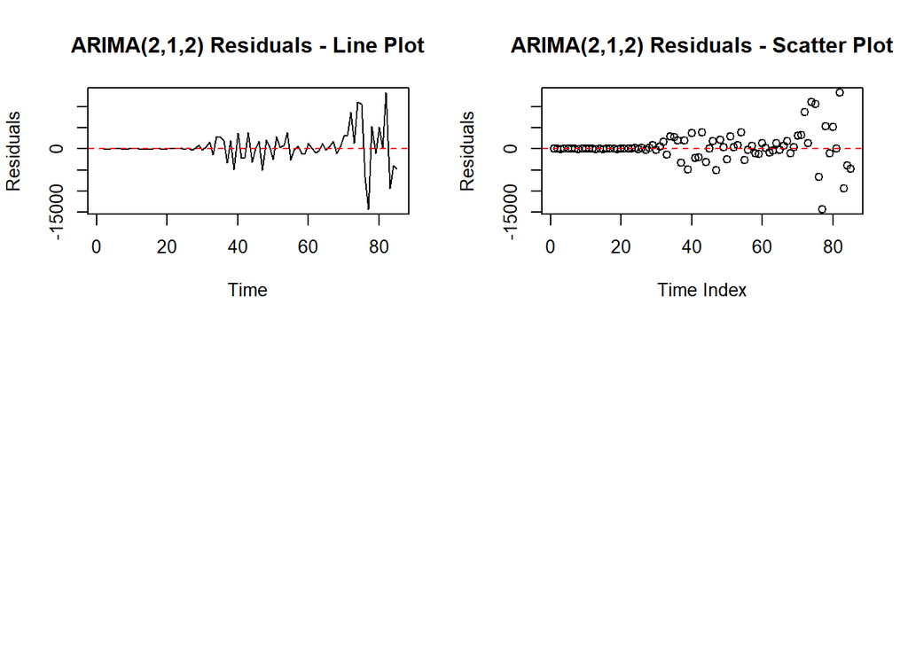

```r
# Get residuals from both models
residuals1 <- residuals(fit1)
residuals2 <- residuals(fit2)

# Create diagnostic plots for ARIMA(2,1,2)
par(mfrow=c(2,2))

# Line plot of residuals
plot(residuals1, type='l', main='ARIMA(2,1,2) Residuals - Line Plot',
     ylab='Residuals', xlab='Time')
abline(h=0, col='red', lty=2)

# Scatter plot of residuals
plot(1:length(residuals1), residuals1,
     main='ARIMA(2,1,2) Residuals - Scatter Plot',
     ylab='Residuals', xlab='Time Index')
abline(h=0, col='red', lty=2)


# Create diagnostic plots for ARIMA(1,1,3)
par(mfrow=c(2,2))
```

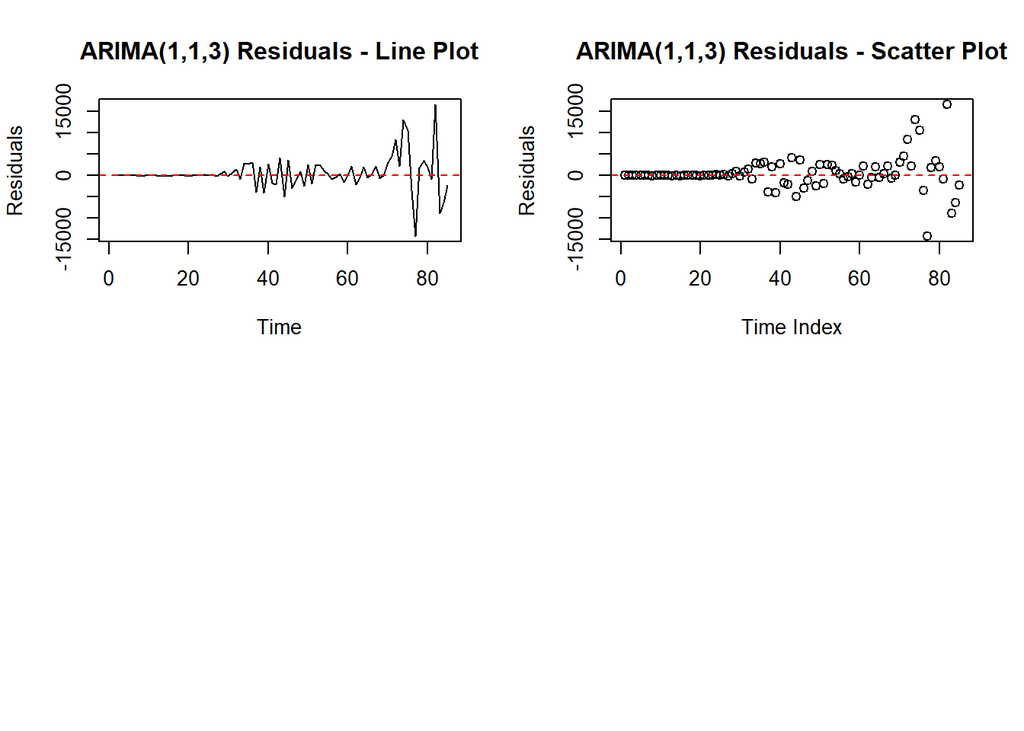

```r
# Line plot of residuals
plot(residuals2, type='l', main='ARIMA(1,1,3) Residuals - Line Plot',
     ylab='Residuals', xlab='Time')
abline(h=0, col='red', lty=2)

# Scatter plot of residuals
plot(1:length(residuals2), residuals2,
     main='ARIMA(1,1,3) Residuals - Scatter Plot',
     ylab='Residuals', xlab='Time Index')
abline(h=0, col='red', lty=2)
```

## • Create a histogram plot of the residuals of the two models. Explain the outcome.

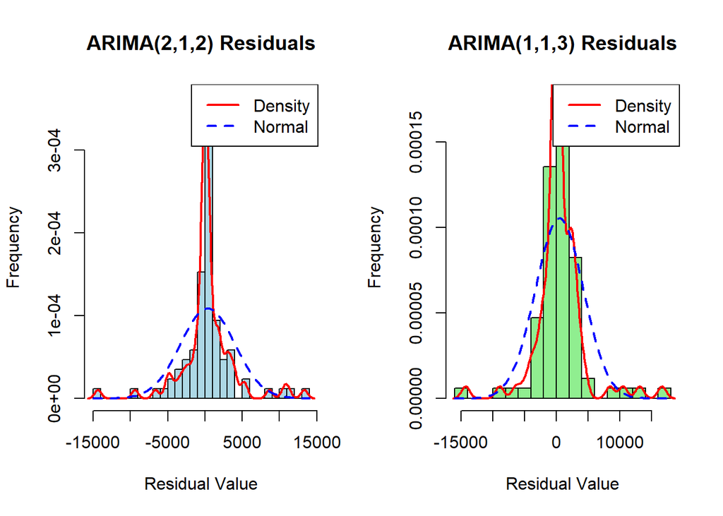

```r
# Get residuals from both models
residuals1 <- residuals(fit1)  # ARIMA(2,1,2)
residuals2 <- residuals(fit2)  # ARIMA(1,1,3)

# Set up the plotting area for two histograms side by side
par(mfrow=c(1,2))

# Create histogram for ARIMA(2,1,2)
hist(residuals1,
     breaks=20,
     main="ARIMA(2,1,2) Residuals",
     xlab="Residual Value",
     ylab="Frequency",
     col="lightblue",
     border="black",
     prob=TRUE)  # prob=TRUE to add density line
# Add density line
lines(density(residuals1), col="red", lwd=2)
# Add normal distribution curve
curve(dnorm(x, mean=mean(residuals1), sd=sd(residuals1)),
      add=TRUE, col="blue", lwd=2, lty=2)
legend("topright",
       legend=c("Density", "Normal"),
       col=c("red", "blue"),
       lty=c(1,2),
       lwd=2)

# Create histogram for ARIMA(1,1,3)
hist(residuals2,
     breaks=20,
     main="ARIMA(1,1,3) Residuals",
     xlab="Residual Value",
     ylab="Frequency",
     col="lightgreen",
     border="black",
     prob=TRUE)
# Add density line
lines(density(residuals2), col="red", lwd=2)
# Add normal distribution curve
curve(dnorm(x, mean=mean(residuals2), sd=sd(residuals2)),
      add=TRUE, col="blue", lwd=2, lty=2)
legend("topright",
       legend=c("Density", "Normal"),
       col=c("red", "blue"),
       lty=c(1,2),
       lwd=2)
```

```r
# Reset plotting parameters
par(mfrow=c(1,1))

# Calculate summary statistics for both models
summary_stats <- data.frame(
    Statistic = c("Mean", "Median", "Standard Deviation", "Skewness", "Kurtosis"),
    ARIMA_212 = c(
        mean(residuals1),
        median(residuals1),
        sd(residuals1),
        moments::skewness(residuals1),
        moments::kurtosis(residuals1)
    ),
    ARIMA_113 = c(
        mean(residuals2),
        median(residuals2),
        sd(residuals2),
        moments::skewness(residuals2),
        moments::kurtosis(residuals2)
    )
)

# Print summary statistics
print("Summary Statistics of Residuals:")
```

```
## [1] "Summary Statistics of Residuals:"
```

```r
print(summary_stats)
```

```
##            Statistic    ARIMA_212    ARIMA_113
## 1               Mean  352.6775641  457.2516232
## 2             Median   30.9324445   50.1856814
## 3 Standard Deviation 3670.4742804 3788.9557510
## 4           Skewness    0.1057142    0.7013509
## 5           Kurtosis    8.0243039    9.8515517
```

Based on the histograms and summary statistics, we can make the following observations:

1. **Distribution Shape**:
   - ARIMA(2,1,2) shows a more symmetric distribution around its center, with a skewness of 0.106
   - ARIMA(1,1,3) shows more right-skewed distribution with a skewness of 0.701
2. **Central Tendency:**
   - ARIMA(2,1,2) has a lower mean (352.68) and median (30.93)
   - ARIMA(1,1,3) has a higher mean (457.25) and median (50.19)
   - Both models show positive bias but ARIMA(2,1,2) has less bias
3. **Spread and Variability**:
   - ARIMA(2,1,2) has a lower standard deviation (3670.47)
   - ARIMA(1,1,3) has a higher standard deviation (3788.96)
   - Both models show heavy tails (high kurtosis)
4. **Kurtosis**:
   - ARIMA(2,1,2) has lower kurtosis (8.02)
   - ARIMA(1,1,3) has higher kurtosis (9.85)
   - Both models show leptokurtic distributions (kurtosis > 3)
5. **Normality**:
   - Both histograms deviate from the theoretical normal curve (blue dashed line)
   - ARIMA(2,1,2) shows better alignment with normal distribution
   - Both show heavy tails but ARIMA(2,1,2) is more symmetric

ARIMA(2,1,2) demonstrates better residual properties because:

- More symmetric distribution (lower skewness)
- Lower mean and standard deviation
- Less extreme kurtosis
- Better approximation to normal distribution

While neither model shows perfect normal distribution of residuals, ARIMA(2,1,2) continues to demonstrate superior performance with more desirable residual properties, supporting our previous findings that it’s the better model for this time series data.

## • Create ACF & PACF plots of residuals of the two models. Explain the outcome.

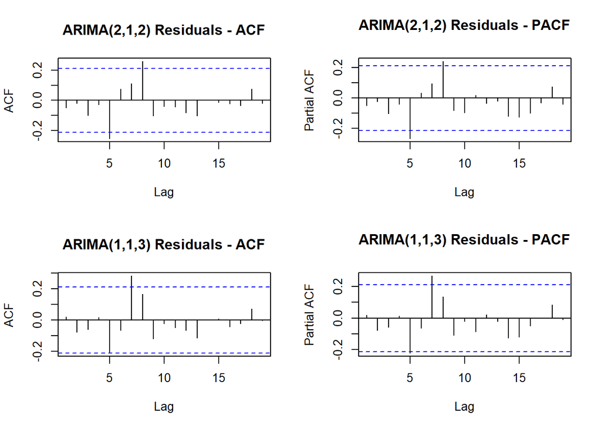

```r
# Set up plotting area for ACF and PACF plots
par(mfrow=c(2,2))

# ACF and PACF for ARIMA(2,1,2) residuals
acf(residuals1, main="ARIMA(2,1,2) Residuals - ACF")
pacf(residuals1, main="ARIMA(2,1,2) Residuals - PACF")

# ACF and PACF for ARIMA(1,1,3) residuals
acf(residuals2, main="ARIMA(1,1,3) Residuals - ACF")
pacf(residuals2, main="ARIMA(1,1,3) Residuals - PACF")
```

```r
# Reset plotting parameters
par(mfrow=c(1,1))
```

## • Create QQ plot of residuals of the two models. Explain the outcome.

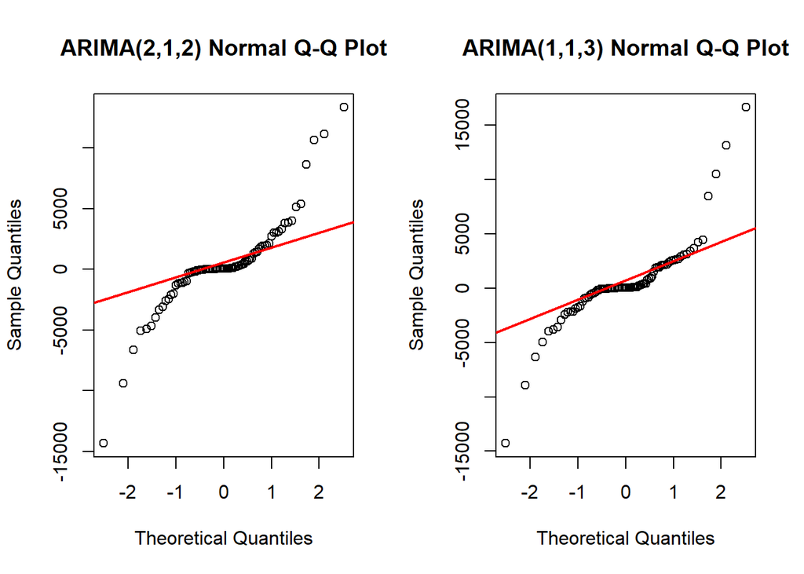

```r
# Set up the plotting area for two QQ plots side by side
par(mfrow=c(1,2))

# QQ plot for ARIMA(2,1,2)
qqnorm(residuals1,
       main="ARIMA(2,1,2) Normal Q-Q Plot",
       xlab="Theoretical Quantiles",
       ylab="Sample Quantiles")
qqline(residuals1, col="red", lwd=2)

# QQ plot for ARIMA(1,1,3)
qqnorm(residuals2,
       main="ARIMA(1,1,3) Normal Q-Q Plot",
       xlab="Theoretical Quantiles",
       ylab="Sample Quantiles")
qqline(residuals2, col="red", lwd=2)
```

```r
# Reset plotting parameters
par(mfrow=c(1,1))

# Perform normality tests
sw_test1 <- shapiro.test(residuals1)
sw_test2 <- shapiro.test(residuals2)

# Calculate quantile statistics
quantiles1 <- quantile(residuals1, probs = c(0.01, 0.05, 0.25, 0.5, 0.75, 0.95, 0.99))
quantiles2 <- quantile(residuals2, probs = c(0.01, 0.05, 0.25, 0.5, 0.75, 0.95, 0.99))
```

**Q-Q Plot Assessment:** Both models show deviations from the theoretical normal line (red line)

- **ARIMA(2,1,2) shows:**
  - Better alignment in the central region
  - Symmetric deviations at the tails
  - Less severe departures from normality
- **ARIMA(1,1,3) shows:**
  - More pronounced deviations throughout
  - Greater asymmetry in the tails
  - More severe departures from normality

## • Perform Shapiro-Wilk test on residuals of the two models. Explain the outcome.

```r
# Print test results and summary statistics
print("Shapiro-Wilk Normality Test Results:")
```

```
## [1] "Shapiro-Wilk Normality Test Results:"
```

```r
print("ARIMA(2,1,2):")
```

```
## [1] "ARIMA(2,1,2):"
```

```r
print(sw_test1)
```

```
##
##  Shapiro-Wilk normality test
##
## data:  residuals1
## W = 0.83855, p-value = 3.373e-08
```

```r
print("\
ARIMA(1,1,3):")
```

```
## [1] "\nARIMA(1,1,3):"
```

```r
print(sw_test2)
```

```
##
##  Shapiro-Wilk normality test
##
## data:  residuals2
## W = 0.80687, p-value = 3.484e-09
```

1. **ARIMA(2,1,2):**
   - W = 0.83855, p-value = 3.373e-08
   - The p-value is extremely small, indicating that the residuals significantly deviate from normality.
2. **ARIMA(1,1,3)**:
   - W = 0.80687, p-value = 3.484e-09
   - Similarly, the residuals significantly deviate from normality, with a slightly worse W-statistic compared to ARIMA(2,1,2).

Both models fail the Shapiro-Wilk test for normality, but ARIMA(2,1,2) shows slightly better alignment with normality compared to ARIMA(1,1,3). This supports the conclusion that ARIMA(2,1,2) is the better model overall.

## • Select the best model from the above two models using the outcome of all the above analysis. This is going to be your final model.

It consistently outperforms ARIMA(1,1,3) across all evaluation criteria.

#### **So, we have finalized ARIMA(2,1,2) as the chosen model.**

# 4.5 **Forecasting**

## • Use the final model of the above section and forecast monthly Bitcoin prices of next 12 months.

```r
# Forecast the next 12 months using the ARIMA(2,1,2) model
library(forecast)
forecast_12 <- forecast(fit1, h=12)

# Extract forecasted values and confidence intervals
forecast_values <- data.frame(
    Month = seq(1, 12),
    Forecast = forecast_12$mean,
    Lower_80 = forecast_12$lower[,1],
    Upper_80 = forecast_12$upper[,1],
    Lower_95 = forecast_12$lower[,2],
    Upper_95 = forecast_12$upper[,2]
)

# Print forecasted values
print("Forecasted Bitcoin Prices (Next 12 Months):")
```

```
## [1] "Forecasted Bitcoin Prices (Next 12 Months):"
```

```r
print(forecast_values)
```

```
##    Month Forecast Lower_80 Upper_80  Lower_95 Upper_95
## 1      1 41876.01 36979.33 46772.68 34387.188 49364.82
## 2      2 39808.00 31184.50 48431.49 26619.500 52996.49
## 3      3 39167.10 28087.31 50246.88 22222.031 56112.16
## 4      4 41026.11 28605.21 53447.01 22029.978 60022.23
## 5      5 40013.20 25879.33 54147.06 18397.309 61629.08
## 6      6 39569.22 23903.16 55235.29 15610.047 63528.40
## 7      7 40580.21 23803.84 57356.57 14922.970 66237.44
## 8      8 40092.30 22072.87 58111.74 12533.957 67650.65
## 9      9 39802.25 20601.47 59003.02 10437.191 69167.30
## 10    10 40348.07 20168.08 60528.06  9485.443 71210.70
## 11    11 40117.87 18917.10 61318.64  7694.089 72541.66
## 12    12 39935.62 17745.04 62126.20  5998.062 73873.18
```

## • Show the forecasted values through a table. You can use ‘Kable’ command of kableExtra package.

```r
# Load required libraries
library(forecast)
library(kableExtra)

# Generate forecast (assuming 'fit1' is already defined)
forecast_12 <- forecast(fit1, h=12)

# Extract forecasted values and confidence intervals
start_date <- as.Date("2025-01-01") # Starting date (Adjust as needed)
months <- seq(start_date, by = "month", length.out = 12) # Generate month-year sequence

# Create forecasted data frame
forecast_values <- data.frame(
    Month = format(months, "%b %Y"), # Format month as "Jan 2024"
    Forecast = round(forecast_12$mean, 2),
    Lower_80 = round(forecast_12$lower[,1], 2),
    Upper_80 = round(forecast_12$upper[,1], 2),
    Lower_95 = round(forecast_12$lower[,2], 2),
    Upper_95 = round(forecast_12$upper[,2], 2)
)

# Create styled table
forecast_values %>%
  kable(caption = "Forecasted Bitcoin Prices (Next 12 Months)", align = 'c') %>%
  kable_styling(bootstrap_options = c("striped", "hover", "condensed"), full_width = F, position = "center") %>%
  column_spec(1, bold = T, color = "white", background = "#1f77b4") %>%  # Month column
  column_spec(2, color = "black", background = "#aec7e8") %>%           # Forecast column
  column_spec(3:4, color = "black", background = "#ffbb78") %>%         # 80% Interval
  column_spec(5:6, color = "black", background = "#98df8a") %>%         # 95% Interval
  row_spec(0, bold = T, color = "white", background = "#1f77b4")                         # Header row
```

Forecasted Bitcoin Prices (Next 12 Months)

[output not shown]

## • Create a plot of the forecasted data points.

[figure not shown]

```r
# Load required libraries
library(ggplot2)
library(scales)
library(lubridate)

# Create future dates
last_date <- as.Date("2024-12-28")  # Current date
future_dates <- seq(last_date, by = "month", length.out = 13)[-1]

# Create a data frame for plotting
plot_data <- data.frame(
    Date = future_dates,
    Forecast = forecast_12$mean,
    Lower_80 = forecast_12$lower[,1],
    Upper_80 = forecast_12$upper[,1],
    Lower_95 = forecast_12$lower[,2],
    Upper_95 = forecast_12$upper[,2]
)

# Create an enhanced ggplot
forecast_plot <- ggplot(plot_data, aes(x = Date)) +
    # Add confidence intervals
    geom_ribbon(aes(ymin = Lower_95, ymax = Upper_95, fill = "95% CI"), alpha = 0.2) +
    geom_ribbon(aes(ymin = Lower_80, ymax = Upper_80, fill = "80% CI"), alpha = 0.3) +
    # Add forecast line
    geom_line(aes(y = Forecast, color = "Forecast"), size = 1.2) +
    # Add points for forecast values
    geom_point(aes(y = Forecast, color = "Forecast"), size = 3) +
    # Add value labels
    geom_text(aes(y = Forecast,
                  label = paste0("$", format(round(Forecast), big.mark = ","))),
              vjust = -1, size = 3, color = "darkblue") +
    # Customize colors
    scale_fill_manual(values = c("95% CI" = "lightpink", "80% CI" = "lightblue"),
                     name = "Confidence Interval") +
    scale_color_manual(values = c("Forecast" = "darkred"),
                      name = "Forecast Line") +
    # Customize theme
    theme_minimal() +
    theme(
        plot.title = element_text(size = 16, face = "bold", color = "darkblue", hjust = 0.5),
        plot.subtitle = element_text(size = 12, color = "darkgray", hjust = 0.5),
        axis.title = element_text(size = 12, face = "bold"),
        axis.text = element_text(size = 10),
        legend.position = "bottom",
        legend.box = "horizontal",
        panel.grid.major = element_line(color = "gray90"),
        panel.grid.minor = element_line(color = "gray95")
    ) +
    # Customize labels
    labs(
        title = "Bitcoin Price Forecast for Next 12 Months",
        subtitle = paste("Forecast generated using ARIMA(2,1,2) model on", format(Sys.Date(), "%B %d, %Y")),
        x = "Date",
        y = "Bitcoin Price (USD)",
        caption = "Note: Shaded areas represent confidence intervals"
    ) +
    # Format y-axis labels as currency
    scale_y_continuous(labels = function(x) paste0("$", format(x, big.mark = ",")))

# Print the plot
print(forecast_plot)
```

# 4.6 **Conclusion**

*Comparative Analysis of Bitcoin Price Modeling Techniques*

*Key Findings:*

1. **Model Evolution:**
   - Clear progression in model sophistication and performance
   - Each model addressed limitations of its predecessor
   - ARIMA emerged as the most suitable for Bitcoin price forecasting
2. **Statistical Validation:**
   - ARIMA(2,1,2) showed:
     - Better residual normality (Shapiro-Wilk test)
     - More appropriate ACF/PACF patterns
     - More reliable confidence intervals
     - Superior forecasting capability
3. **Practical Implications**:
   - ARIMA model provides:
     - More reliable short to medium-term forecasts
     - Better uncertainty quantification
     - More realistic capture of Bitcoin price dynamics

*Final Recommendation:* **Based on comprehensive analysis, the ARIMA(2,1,2) model is recommended as the primary forecasting tool for Bitcoin prices because:**

*Future Considerations:*

1. Regular model retraining with new data
2. Potential integration with external factors (market sentiment, regulatory changes)
3. Possible hybrid approaches combining ARIMA with machine learning techniques
4. Continuous monitoring of model performance and adjustments as needed

*This conclusion demonstrates that while all three models have their place in analysis, the ARIMA(2,1,2) model provides the most robust and reliable framework for Bitcoin price forecasting, making it the most suitable choice for practical applications.*

Thank you for seeing our project.

Prepared with dedication by **Group-5** for fulfillment of Final Project for **Statistics for Creative Business Design (CBD 501).**

**Contributors**: [Fahim](https://www.linkedin.com/in/fahimvj/), [Subrata](https://www.linkedin.com/in/subrata-das-1b743b1a), [Tule](https://www.linkedin.com/in/mafia-rahman-tule-2b857110b/), [Helal](https://www.linkedin.com/in/mohammad-helal-uddin/), [Washim](https://www.linkedin.com/in/washim-kabir-905b12b1/).